# Data_analysis_PE_rhizoboxes

Benjamin Delory and Inés Alonso-Crespo

15/11/2021

## Load R packages

```r
library(ggplot2)
library(ggpubr)
library(ggsignif)
library(lme4)
library(emmeans)
library(lmerTest)
library(Hmisc)
library(ggeffects)
library(MASS)
library(viridis)
library(sp)
library(stringr)
library(dplyr)
```

## Create function to calculate MRD and D90 from root biomass data

The `vrd` function calculates the following parameters for each rhizobox:

- **RDWtotal**: the total root dry weight (mg)
- **MRD**: mean rooting depth (cm) following Mommer et al (2010) [Unveiling below-ground species abundance in a biodiversity experiment: a test of vertical niche differentiation among grassland species](https://besjournals.onlinelibrary.wiley.com/doi/full/10.1111/j.1365-2745.2010.01702.x). *Journal of Ecology*, 98, 1117-1127.
- **beta**: parameter of the asymptotic equation used to model the relationship between the cumulative proportion of root biomass (C) and soil depth (d). A description of the model can be found in Gale and Grigal (1987). [Vertical root distributions of northern tree species in relation to successional status](https://www.nrcresearchpress.com/doi/10.1139/x87-131#.Xyp3UjVS-70). *Can J For Res*, 17, 829-834.
  $$C=1-\beta^d$$
- **D90**: depth value (in cm) above which 90% of the root biomass lies.
  $$D90=\frac{log(0.1)}{log(\beta)}$$

```r
vrd<-function(x, data, depth, replicate, D=90){

  #x is a formula: response~factor
  #data is a data frame with the raw data
  #depth is the name of the column with maxDepth values (character string)
  #replicate is the name of the column with replicate IDs (character string)
  #D is the depth threshold (in %)

  if (class(x)=="formula"){

    response<-as.character(x[[2]])
    factor<-as.character(x[[3]])}

  res<-aggregate(data[,response], by=list(Treatment=data[,factor], Rz=data[,"Rz"], Replicate=data[,replicate]), sum)
  meanRDW<-aggregate(data[,response], by=list(Treatment=data[,factor], Rz=data[,"Rz"], Replicate=data[,replicate]), mean)
  sdRDW<-aggregate(data[,response], by=list(Treatment=data[,factor], Rz=data[,"Rz"], Replicate=data[,replicate]), sd)
  colnames(res)[4]<-"RDWtotal"
  res$MRD<-NA
  res$beta<-NA
  res<-res[order(res$Treatment),]

  for (i in 1:nrow(res)){

    sub<-data[data[,factor]==res$Treatment[i] & data[,replicate]==res$Replicate[i], c(factor, replicate, depth, response)]
    sub[,factor]<-as.character(sub[,factor])
    sub[nrow(sub)+1,]<-c(sub[1,factor], sub[1,replicate], 0, 0)
    sub[,response]<-as.numeric(sub[,response])
    sub[,depth]<-as.numeric(sub[,depth])
    sub<-sub[order(sub[,depth]),]
    sub[,response]<-cumsum(sub[,response])/sum(sub[,response])

    r<-sub[,response]
    d<-sub[,depth]

    model<-nls(r~1-beta^d, start=list(beta=1)) #Fit model

    res$beta[i]<-coef(model)

    res$MRD[i]<-sum((sub[,response]/sum(sub[,response]))*(sub[,depth]-5))}

  if (D<100) {res[,paste("D", D, sep="")]<-log(1-(D/100))/log(res$beta)} else {stop("D must be smaller than 100")}

  res$invCV<-meanRDW$x/sdRDW$x

  return(res[,c(2,1,3:8)])}
```

## Create function to calculate unstandardised effect sizes

`bootstrap_ES` is an R function calculating unstandardised effect sizes for each treatment and their compatibility intervals (bootstrap resampling using the percentile method) for one response variable. The number of bootstrap resamples is set using `n_perm` (default to 20000). The argument `plot` can be used to create a histogram displaying the results.

This function is a modified version of the [function coded by Masahiro Ryo](https://github.com/masahiroryo/joint-ES-estimate/blob/master/20190801_analysis_v2.0.R) for the following paper: [Rillig et al (2019). The role of multiple global change factors in driving soil functions and microbial biodiversity. Science, 366, 886-890](https://science.sciencemag.org/content/366/6467/886).

```r
bootstrap_ES <- function(response, data=data, contr, n_perm = 20000, plot=FALSE){

  #response is the response variable
  #data is a data frame with the raw data
  #contr is a vector of contrasts (factor level separated by "/", no space)

  summary <- data.frame(Contrast=NA, lowCI=NA, ES=NA, highCI=NA, relES=NA)
  alles <- data.frame()
  row<-0

    for (c in contr){

      split<-strsplit(c, "/")[[1]]

      bs <- numeric(0)
      population_1 <- na.omit(data[data$Treatment==split[1], response])
      population_2 <- na.omit(data[data$Treatment==split[2], response])
      size_1 <- length(population_1)
      size_2 <- length(population_2)

      if (size_1==0|size_2==0){} else {

        row<-row+1

        set.seed(123) #For reproducibility

        for (i in c(1:n_perm)){

          k_1 <- mean(sample(population_1, size_1, replace = T))
          k_2 <- mean(sample(population_2, size_2, replace = T))
          bs <- append(bs, k_1-k_2)}

      summary[row,1] <- c
      summary[row,2:4] <- c(quantile(bs, .025), mean(population_1)-mean(population_2), quantile(bs, .975))
      summary[row,5] <- 100*(mean(population_1)-mean(population_2))/mean(population_2)
      alles<-rbind(alles, data.frame(Contrast=rep(c, n_perm), ES=bs))}

      if (plot==TRUE){
        hist(bs, main=c, xlab=paste("ES", response, sep=" "))
        points(mean(population_1)-mean(population_2), 0, pch=16, cex=2, col="red")
        segments(x0=quantile(bs, .025), y0=0, x1=quantile(bs, .975), y1=0, lwd=2, col="red")}}

  return(list(summary=summary, bootstrap=alles))}
```

## Analysis of shoot biomass data

### Load data

```r
shoot <- read.delim("Z:/Poem/Rhizoboxes/0_Rz_experiment_data/Data/Data_shoot_biomass_RZ_PE_2017.txt")
shoot<-as.data.frame(shoot)
shoot$Treatment<-as.factor(shoot$Treatment)

#Convert data in mg
shoot[,4:16]<-shoot[,4:16]*1000

#Remove rhizoboxes where Lotus corniculatus did not grow
shoot<-na.omit(shoot)

#Prepare data for ggplot
shoot1<-data.frame(Treatment=rep(shoot$Treatment, 9),
                   Replicate=rep(shoot$Replicate, 9),
                   Species=rep(c("Trifolium pratense", "Lotus corniculatus", "Medicago sativa", "Festuca rubra", "Holcus lanatus", "Dactylis glomerata", "Centaurea jacea", "Leucanthemum vulgare", "Achillea millefolium"), each=31),
                   SDW=as.vector(as.matrix(shoot[,4:12])))
```

### Plot total shoot biomass

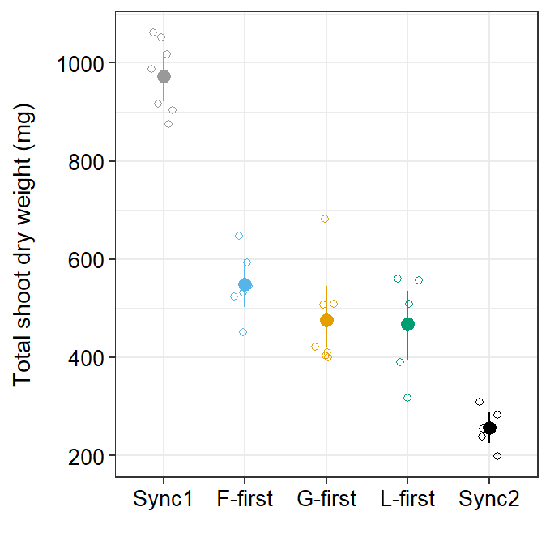

```r
shoot$Treatment<-factor(shoot$Treatment, levels=c("Sync1", "F-first", "G-first", "L-first", "Sync2"))
colors<-c("#999999", "#56B4E9", "#E69F00", "#009E73", "black")

(p2<-ggplot(shoot, aes(x=Treatment, y=Total, color=Treatment)) +
    geom_jitter(shape=1, width=0.15) +
    labs(x = "", y = "Total shoot dry weight (mg)") +
    theme_bw()+
    stat_summary(fun.data="mean_cl_boot", size=0.5)+
    scale_color_manual(values=colors)+
    theme(legend.position = "none",
          axis.text=element_text(size=10, color="black"),
          axis.title.y = element_text(margin=margin(t=0,b=0,r=10,l=0)),
          axis.text.x=element_text(angle=0)))
```

```r
#ggsave("Total_shoot_productivity.tiff", p2, dpi=1000, compression="lzw", width=9, height=9, units="cm")
```

### Effect sizes

#### *Achillea millefolium*

```r
es.Am<-bootstrap_ES(response="Am", data=shoot, contr=c("F-first/Sync1", "G-first/Sync2", "L-first/Sync2", "G-first/L-first"), plot=FALSE)
knitr::kable(es.Am$summary)
```

| Contrast | lowCI | ES | highCI | relES |
| --- | --- | --- | --- | --- |
| F-first/Sync1 | 11.578810 | 52.5740476 | 96.240958 | 86.735407 |
| G-first/Sync2 | -5.447157 | -0.7791429 | 4.181443 | -7.411937 |
| L-first/Sync2 | -6.920675 | -2.4103333 | 2.208533 | -22.929351 |
| G-first/L-first | -1.845958 | 1.6311905 | 5.501940 | 20.134011 |

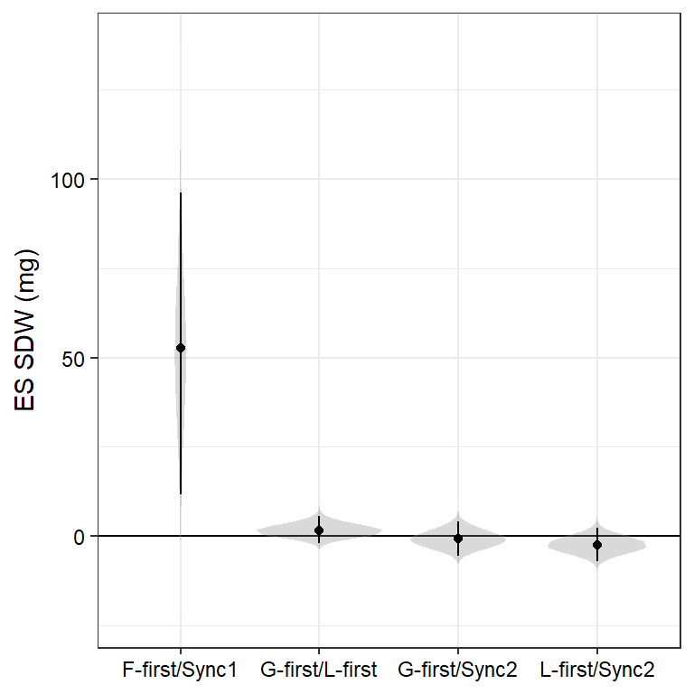

```r
ggplot(es.Am$bootstrap)+
  geom_hline(yintercept = 0)+
  stat_ydensity(aes(x=Contrast, y=ES), fill="grey50", color=adjustcolor("white", alpha.f = 0.1), alpha=0.3)+
  geom_segment(data=es.Am$summary, aes(x=Contrast, xend=Contrast, y=lowCI, yend=highCI), color="black", size=0.5)+
  geom_point(data=es.Am$summary, aes(x=Contrast, y=ES), shape=16, color="black")+
  theme_bw()+
  xlab("")+
  ylab("ES SDW (mg)")+
  theme(axis.title=element_text(color="black", face="plain"),
  axis.title.y=element_text(margin = margin(t = 0, r = 5, b = 0, l = 0)),
  axis.title.x=element_blank(),
  axis.text=element_text(color="black"))
```

#### *Centaurea jacea*

```r
es.Cj<-bootstrap_ES(response="Cj", data=shoot, contr=c("F-first/Sync1", "G-first/Sync2", "L-first/Sync2", "G-first/L-first"), plot=FALSE)
knitr::kable(es.Cj$summary)
```

| Contrast | lowCI | ES | highCI | relES |
| --- | --- | --- | --- | --- |
| F-first/Sync1 | 36.250238 | 71.274048 | 107.19702 | 67.04089 |
| G-first/Sync2 | -84.578643 | -25.935714 | 10.88806 | -52.59727 |
| L-first/Sync2 | -89.128725 | -30.936667 | 5.44140 | -62.73913 |
| G-first/L-first | -5.397494 | 5.000952 | 15.77407 | 27.21854 |

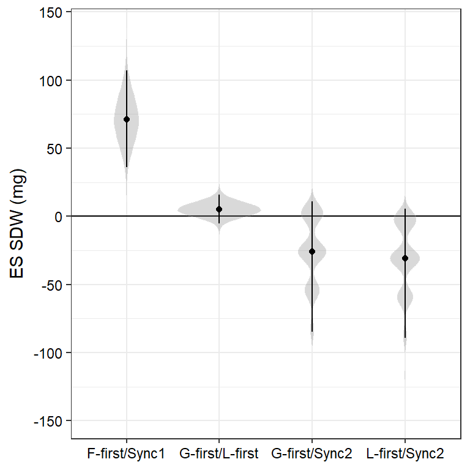

```r
ggplot(es.Cj$bootstrap)+
  geom_hline(yintercept = 0)+
  stat_ydensity(aes(x=Contrast, y=ES), fill="grey50", color=adjustcolor("white", alpha.f = 0.1), alpha=0.3)+
  geom_segment(data=es.Cj$summary, aes(x=Contrast, xend=Contrast, y=lowCI, yend=highCI), color="black", size=0.5)+
  geom_point(data=es.Cj$summary, aes(x=Contrast, y=ES), shape=16, color="black")+
  theme_bw()+
  xlab("")+
  ylab("ES SDW (mg)")+
  theme(axis.title=element_text(color="black", face="plain"),
  axis.title.y=element_text(margin = margin(t = 0, r = 5, b = 0, l = 0)),
  axis.title.x=element_blank(),
  axis.text=element_text(color="black"))
```

#### *Leucanthemum vulgare*

```r
es.Lv<-bootstrap_ES(response="Lv", data=shoot, contr=c("F-first/Sync1", "G-first/Sync2", "L-first/Sync2", "G-first/L-first"), plot=FALSE)
knitr::kable(es.Lv$summary)
```

| Contrast | lowCI | ES | highCI | relES |
| --- | --- | --- | --- | --- |
| F-first/Sync1 | -19.749756 | 9.319762 | 39.939059 | 10.02679 |
| G-first/Sync2 | -12.231507 | -2.668857 | 8.053436 | -12.88307 |
| L-first/Sync2 | -13.625283 | -5.392667 | 4.629875 | -26.03141 |
| G-first/L-first | -3.178429 | 2.723810 | 8.423833 | 17.77557 |

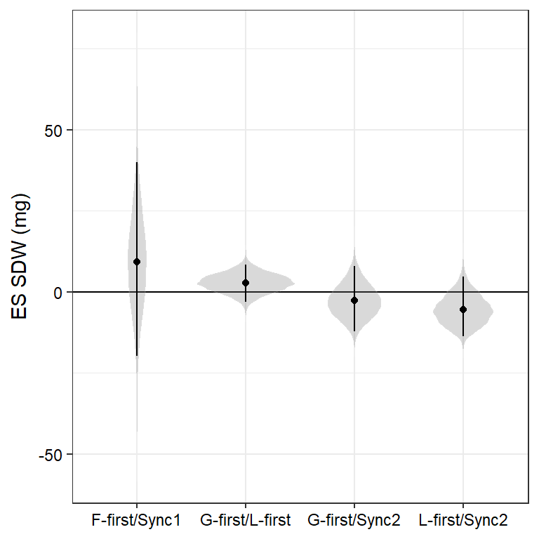

```r
ggplot(es.Lv$bootstrap)+
  geom_hline(yintercept = 0)+
  stat_ydensity(aes(x=Contrast, y=ES), fill="grey50", color=adjustcolor("white", alpha.f = 0.1), alpha=0.3)+
  geom_segment(data=es.Lv$summary, aes(x=Contrast, xend=Contrast, y=lowCI, yend=highCI), color="black", size=0.5)+
  geom_point(data=es.Lv$summary, aes(x=Contrast, y=ES), shape=16, color="black")+
  theme_bw()+
  xlab("")+
  ylab("ES SDW (mg)")+
  theme(axis.title=element_text(color="black", face="plain"),
  axis.title.y=element_text(margin = margin(t = 0, r = 5, b = 0, l = 0)),
  axis.title.x=element_blank(),
  axis.text=element_text(color="black"))
```

#### *Dactylis glomerata*

```r
es.Dg<-bootstrap_ES(response="Dg", data=shoot, contr=c("G-first/Sync1", "F-first/Sync2", "L-first/Sync2", "F-first/L-first"), plot=FALSE)
knitr::kable(es.Dg$summary)
```

| Contrast | lowCI | ES | highCI | relES |
| --- | --- | --- | --- | --- |
| G-first/Sync1 | -45.913107 | -13.5771429 | 19.557750 | -9.023499 |
| F-first/Sync2 | -8.823333 | -3.1780000 | 2.711850 | -10.636589 |
| L-first/Sync2 | -12.002817 | -3.6263333 | 4.021200 | -12.137135 |
| F-first/L-first | -6.698333 | 0.4483333 | 8.290042 | 1.707828 |

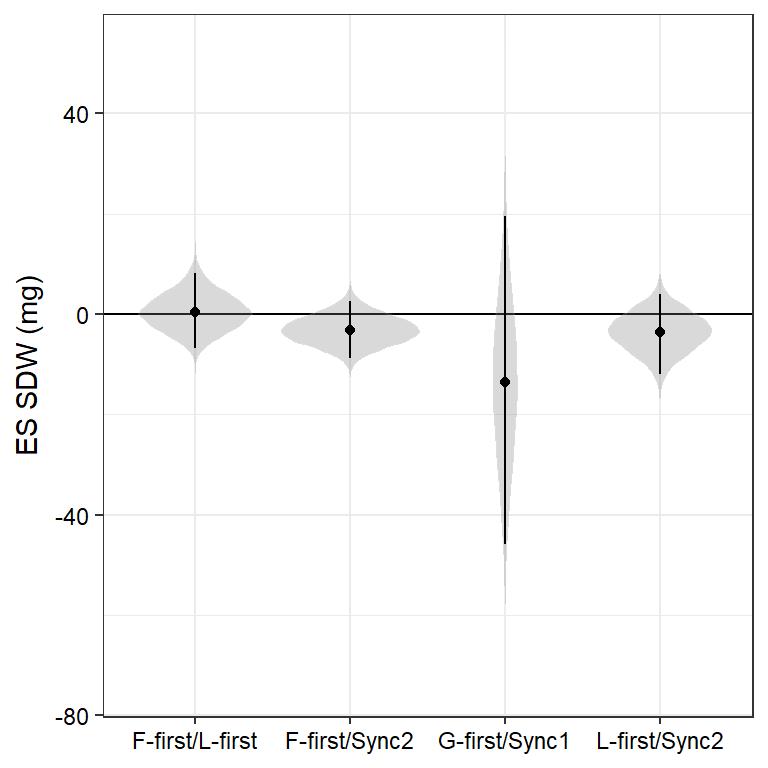

```r
ggplot(es.Dg$bootstrap)+
  geom_hline(yintercept = 0)+
  stat_ydensity(aes(x=Contrast, y=ES), fill="grey50", color=adjustcolor("white", alpha.f = 0.1), alpha=0.3)+
  geom_segment(data=es.Dg$summary, aes(x=Contrast, xend=Contrast, y=lowCI, yend=highCI), color="black", size=0.5)+
  geom_point(data=es.Dg$summary, aes(x=Contrast, y=ES), shape=16, color="black")+
  theme_bw()+
  xlab("")+
  ylab("ES SDW (mg)")+
  theme(axis.title=element_text(color="black", face="plain"),
  axis.title.y=element_text(margin = margin(t = 0, r = 5, b = 0, l = 0)),
  axis.title.x=element_blank(),
  axis.text=element_text(color="black"))
```

#### *Festuca rubra*

```r
es.Fr<-bootstrap_ES(response="Fr", data=shoot, contr=c("G-first/Sync1", "F-first/Sync2", "L-first/Sync2", "F-first/L-first"), plot=FALSE)
knitr::kable(es.Fr$summary)
```

| Contrast | lowCI | ES | highCI | relES |
| --- | --- | --- | --- | --- |
| G-first/Sync1 | -7.820036 | 0.4571429 | 9.655821 | 1.148971 |
| F-first/Sync2 | -4.303050 | 1.0393333 | 6.057667 | 17.784622 |
| L-first/Sync2 | -4.414333 | 0.2893333 | 4.712667 | 4.950947 |
| F-first/L-first | -2.473333 | 0.7500000 | 3.750042 | 12.228261 |

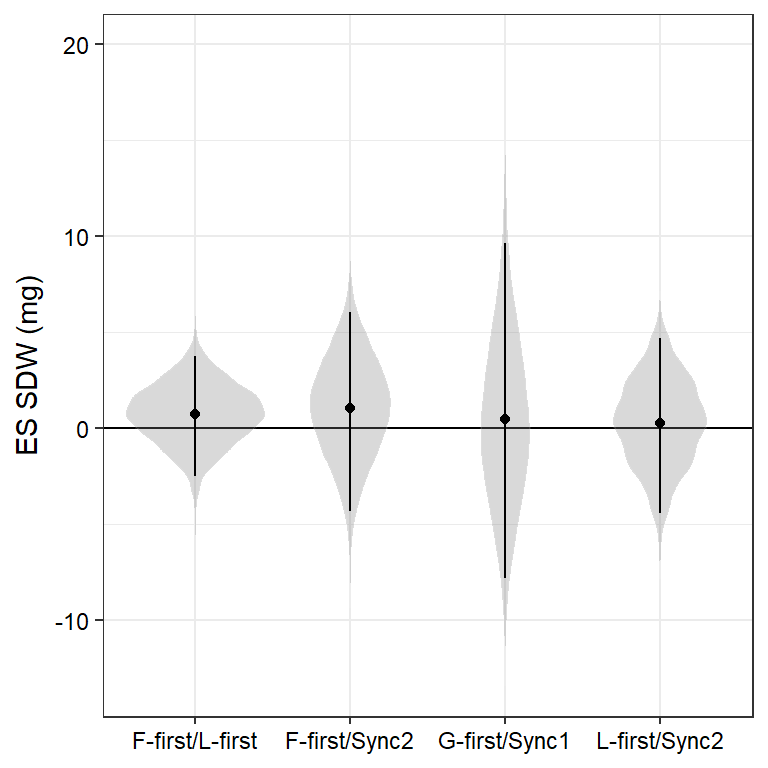

```r
ggplot(es.Fr$bootstrap)+
  geom_hline(yintercept = 0)+
  stat_ydensity(aes(x=Contrast, y=ES), fill="grey50", color=adjustcolor("white", alpha.f = 0.1), alpha=0.3)+
  geom_segment(data=es.Fr$summary, aes(x=Contrast, xend=Contrast, y=lowCI, yend=highCI), color="black", size=0.5)+
  geom_point(data=es.Fr$summary, aes(x=Contrast, y=ES), shape=16, color="black")+
  theme_bw()+
  xlab("")+
  ylab("ES SDW (mg)")+
  theme(axis.title=element_text(color="black", face="plain"),
  axis.title.y=element_text(margin = margin(t = 0, r = 5, b = 0, l = 0)),
  axis.title.x=element_blank(),
  axis.text=element_text(color="black"))
```

#### *Holcus lanatus*

```r
es.Hl<-bootstrap_ES(response="Hl", data=shoot, contr=c("G-first/Sync1", "F-first/Sync2", "L-first/Sync2", "F-first/L-first"), plot=FALSE)
knitr::kable(es.Hl$summary)
```

| Contrast | lowCI | ES | highCI | relES |
| --- | --- | --- | --- | --- |
| G-first/Sync1 | -38.271750 | 8.782857 | 59.175857 | 6.388329 |
| F-first/Sync2 | -11.636375 | -4.155000 | 3.415075 | -29.055944 |
| L-first/Sync2 | -10.111333 | -4.400000 | 1.321333 | -30.769231 |
| F-first/L-first | -6.998458 | 0.245000 | 7.488500 | 2.474747 |

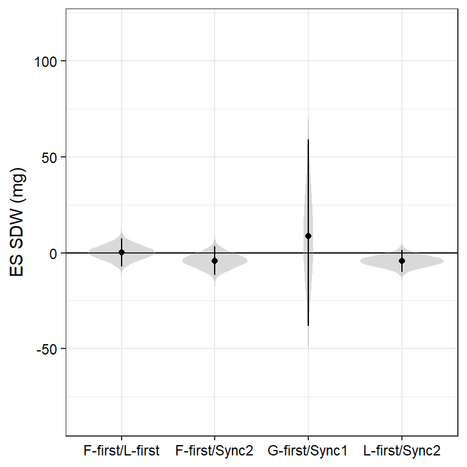

```r
ggplot(es.Hl$bootstrap)+
  geom_hline(yintercept = 0)+
  stat_ydensity(aes(x=Contrast, y=ES), fill="grey50", color=adjustcolor("white", alpha.f = 0.1), alpha=0.3)+
  geom_segment(data=es.Hl$summary, aes(x=Contrast, xend=Contrast, y=lowCI, yend=highCI), color="black", size=0.5)+
  geom_point(data=es.Hl$summary, aes(x=Contrast, y=ES), shape=16, color="black")+
  theme_bw()+
  xlab("")+
  ylab("ES SDW (mg)")+
  theme(axis.title=element_text(color="black", face="plain"),
  axis.title.y=element_text(margin = margin(t = 0, r = 5, b = 0, l = 0)),
  axis.title.x=element_blank(),
  axis.text=element_text(color="black"))
```

#### *Lotus corniculatus*

```r
es.Lc<-bootstrap_ES(response="Lc", data=shoot, contr=c("L-first/Sync1", "F-first/Sync2", "G-first/Sync2", "F-first/G-first"), plot=FALSE)
knitr::kable(es.Lc$summary)
```

| Contrast | lowCI | ES | highCI | relES |
| --- | --- | --- | --- | --- |
| L-first/Sync1 | -18.346214 | -0.5166667 | 18.913381 | -1.222590 |
| F-first/Sync2 | -7.979017 | -2.5560000 | 2.419575 | -21.096071 |
| G-first/Sync2 | -6.556586 | -0.8860000 | 4.738357 | -7.312644 |
| F-first/G-first | -6.781667 | -1.6700000 | 3.104065 | -14.870882 |

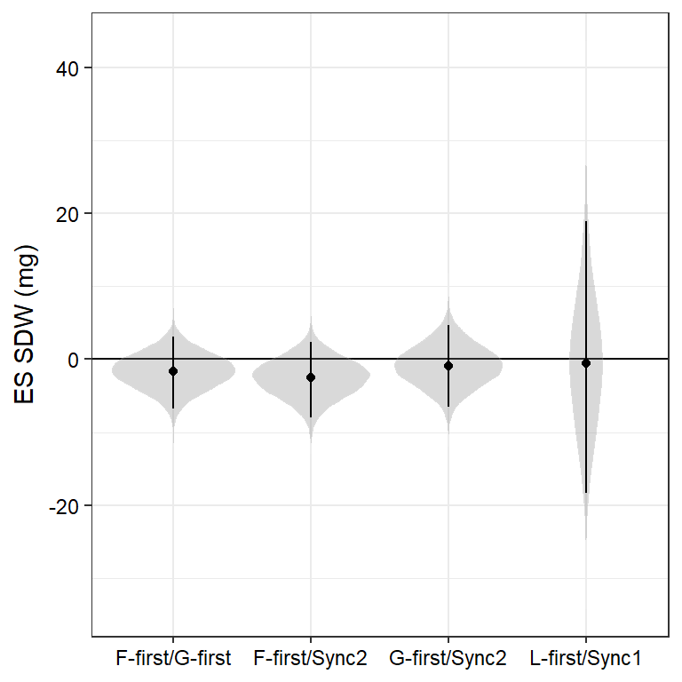

```r
ggplot(es.Lc$bootstrap)+
  geom_hline(yintercept = 0)+
  stat_ydensity(aes(x=Contrast, y=ES), fill="grey50", color=adjustcolor("white", alpha.f = 0.1), alpha=0.3)+
  geom_segment(data=es.Lc$summary, aes(x=Contrast, xend=Contrast, y=lowCI, yend=highCI), color="black", size=0.5)+
  geom_point(data=es.Lc$summary, aes(x=Contrast, y=ES), shape=16, color="black")+
  theme_bw()+
  xlab("")+
  ylab("ES SDW (mg)")+
  theme(axis.title=element_text(color="black", face="plain"),
  axis.title.y=element_text(margin = margin(t = 0, r = 5, b = 0, l = 0)),
  axis.title.x=element_blank(),
  axis.text=element_text(color="black"))
```

#### *Medicago sativa*

```r
es.Ms<-bootstrap_ES(response="Ms", data=shoot, contr=c("L-first/Sync1", "F-first/Sync2", "G-first/Sync2", "F-first/G-first"), plot=FALSE)
knitr::kable(es.Ms$summary)
```

| Contrast | lowCI | ES | highCI | relES |
| --- | --- | --- | --- | --- |
| L-first/Sync1 | -115.36010 | -23.928809 | 64.976494 | -10.038215 |
| F-first/Sync2 | -25.36776 | -6.472667 | 12.394667 | -8.660708 |
| G-first/Sync2 | -30.61861 | -10.498857 | 9.192579 | -14.047925 |
| F-first/G-first | -19.09219 | 4.026191 | 27.406917 | 6.267699 |

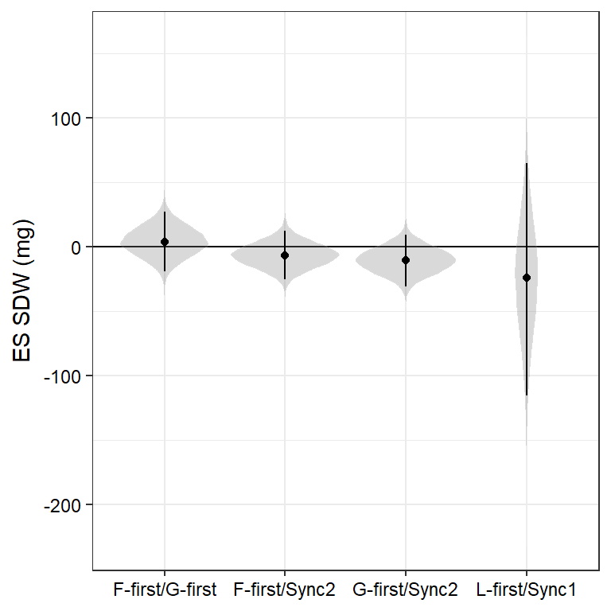

```r
ggplot(es.Ms$bootstrap)+
  geom_hline(yintercept = 0)+
  stat_ydensity(aes(x=Contrast, y=ES), fill="grey50", color=adjustcolor("white", alpha.f = 0.1), alpha=0.3)+
  geom_segment(data=es.Ms$summary, aes(x=Contrast, xend=Contrast, y=lowCI, yend=highCI), color="black", size=0.5)+
  geom_point(data=es.Ms$summary, aes(x=Contrast, y=ES), shape=16, color="black")+
  theme_bw()+
  xlab("")+
  ylab("ES SDW (mg)")+
  theme(axis.title=element_text(color="black", face="plain"),
  axis.title.y=element_text(margin = margin(t = 0, r = 5, b = 0, l = 0)),
  axis.title.x=element_blank(),
  axis.text=element_text(color="black"))
```

#### *Trifolium pratense*

```r
es.Tp<-bootstrap_ES(response="Tp", data=shoot, contr=c("L-first/Sync1", "F-first/Sync2", "G-first/Sync2", "G-first/F-first"), plot=FALSE)
knitr::kable(es.Tp$summary)
```

| Contrast | lowCI | ES | highCI | relES |
| --- | --- | --- | --- | --- |
| L-first/Sync1 | -2.413631 | 22.454286 | 47.3319464 | 21.47796 |
| F-first/Sync2 | -17.259392 | -5.202667 | 7.0843333 | -13.25318 |
| G-first/Sync2 | -24.240300 | -13.258857 | -1.8465929 | -33.77536 |
| G-first/F-first | -15.747232 | -8.056190 | -0.1942738 | -23.65757 |

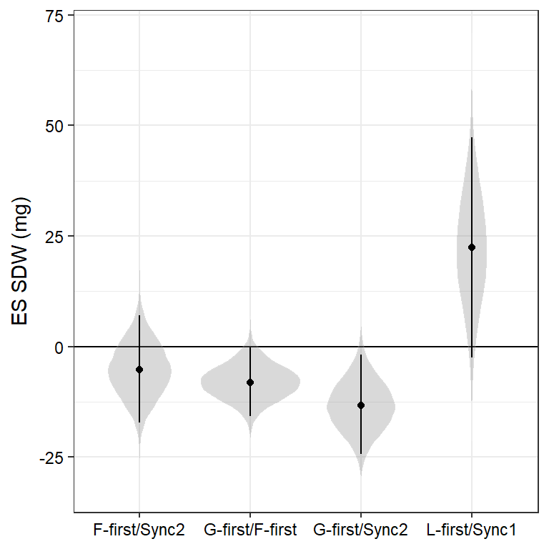

```r
ggplot(es.Tp$bootstrap)+
  geom_hline(yintercept = 0)+
  stat_ydensity(aes(x=Contrast, y=ES), fill="grey50", color=adjustcolor("white", alpha.f = 0.1), alpha=0.3)+
  geom_segment(data=es.Tp$summary, aes(x=Contrast, xend=Contrast, y=lowCI, yend=highCI), color="black", size=0.5)+
  geom_point(data=es.Tp$summary, aes(x=Contrast, y=ES), shape=16, color="black")+
  theme_bw()+
  xlab("")+
  ylab("ES SDW (mg)")+
  theme(axis.title=element_text(color="black", face="plain"),
  axis.title.y=element_text(margin = margin(t = 0, r = 5, b = 0, l = 0)),
  axis.title.x=element_blank(),
  axis.text=element_text(color="black"))
```

#### Total shoot biomass

```r
es.Total<-bootstrap_ES(response="Total", data=shoot, contr=c("F-first/G-first", "F-first/L-first", "G-first/L-first"), plot=FALSE)
knitr::kable(es.Total$summary)
```

| Contrast | lowCI | ES | highCI | relES |
| --- | --- | --- | --- | --- |
| F-first/G-first | -16.771786 | 72.634286 | 151.1488 | 15.258800 |
| F-first/L-first | -2.015292 | 81.375000 | 169.0913 | 17.414799 |
| G-first/L-first | -83.829524 | 8.740714 | 111.8048 | 1.870572 |

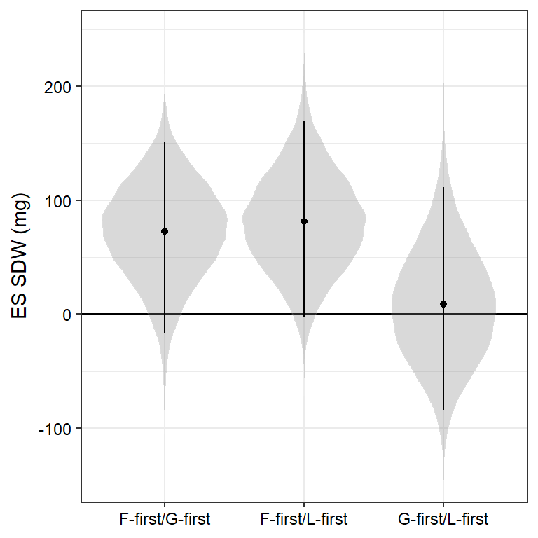

```r
ggplot(es.Total$bootstrap)+
  geom_hline(yintercept = 0)+
  stat_ydensity(aes(x=Contrast, y=ES), fill="grey50", color=adjustcolor("white", alpha.f = 0.1), alpha=0.3)+
  geom_segment(data=es.Total$summary, aes(x=Contrast, xend=Contrast, y=lowCI, yend=highCI), color="black", size=0.5)+
  geom_point(data=es.Total$summary, aes(x=Contrast, y=ES), shape=16, color="black")+
  theme_bw()+
  xlab("")+
  ylab("ES SDW (mg)")+
  theme(axis.title=element_text(color="black", face="plain"),
  axis.title.y=element_text(margin = margin(t = 0, r = 5, b = 0, l = 0)),
  axis.title.x=element_blank(),
  axis.text=element_text(color="black"))
```

### Plot shoot biomass for each species

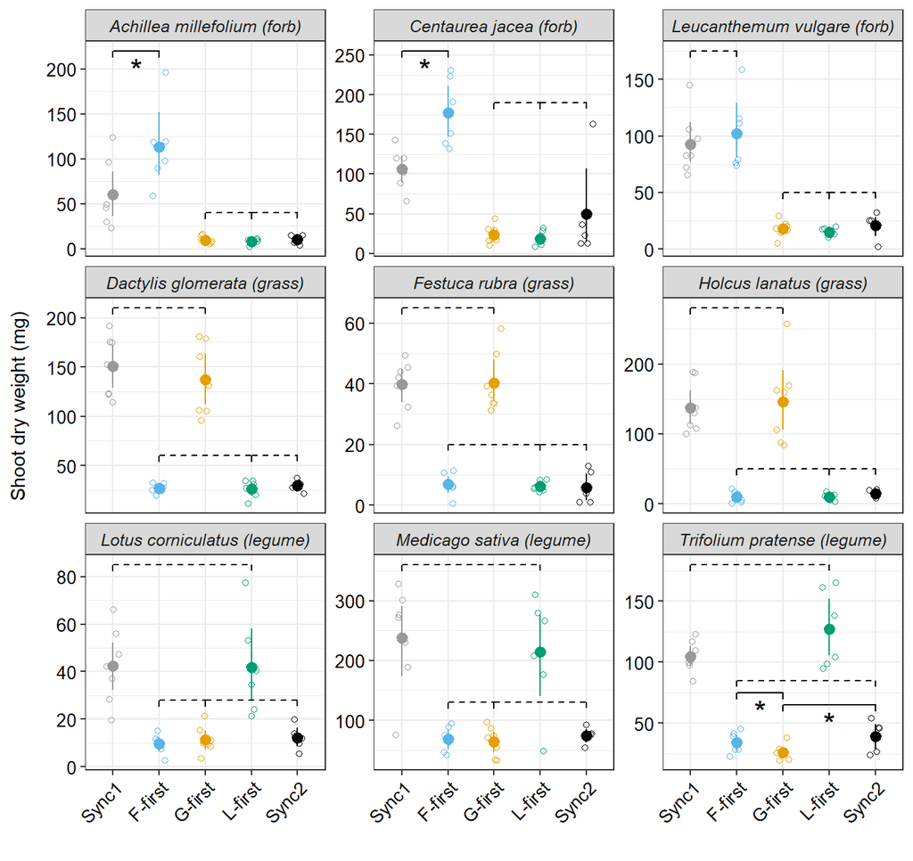

```r
shoot1$Treatment<-factor(shoot1$Treatment, levels=c("Sync1", "F-first", "G-first", "L-first", "Sync2"))
shoot1$Species<-factor(shoot1$Species, levels=c("Achillea millefolium", "Centaurea jacea", "Leucanthemum vulgare", "Dactylis glomerata", "Festuca rubra", "Holcus lanatus", "Lotus corniculatus", "Medicago sativa","Trifolium pratense"))

colors<-c("#999999", "#56B4E9", "#E69F00", "#009E73", "black")

shoot1$PFG<-"Legumes"
shoot1$PFG[which(shoot1$Species=="Achillea millefolium"|
                   shoot1$Species=="Centaurea jacea"|
                   shoot1$Species=="Leucanthemum vulgare")]<-"Forbs"
shoot1$PFG[which(shoot1$Species=="Dactylis glomerata"|
                   shoot1$Species=="Festuca rubra"|
                   shoot1$Species=="Holcus lanatus")]<-"Grasses"

shoot1$PFG<-factor(shoot1$PFG, levels=c("Forbs", "Grasses", "Legumes"))

data_signif_1<-data.frame(
  Species=c("Achillea millefolium", "Centaurea jacea", "Leucanthemum vulgare", "Dactylis glomerata", "Festuca rubra", "Holcus lanatus", "Lotus corniculatus", "Medicago sativa","Trifolium pratense"),
  PFG=c("Forbs", "Forbs", "Forbs", "Grasses", "Grasses", "Grasses","Legumes","Legumes","Legumes"),
  xmin=c(1,1,1,1,1,1,1,1,1),
  xmax=c(2,2,2,3,3,3,4,4,4),
  x=c(1.5,1.5,1.5,2,2,2,2.5,2.5,2.5),
  y=c(220,255,175,210,65,280,85,360,180),
  annotations=c("*", "*","","","","","","",""),
  linetype=c("y","y",rep("n", 7)))

data_signif_2<-data.frame(
  Species=c("Achillea millefolium", "Achillea millefolium",
            "Centaurea jacea", "Centaurea jacea",
            "Leucanthemum vulgare", "Leucanthemum vulgare",
            "Dactylis glomerata", "Dactylis glomerata",
            "Festuca rubra", "Festuca rubra",
            "Holcus lanatus", "Holcus lanatus",
            "Lotus corniculatus", "Lotus corniculatus",
            "Medicago sativa", "Medicago sativa",
            "Trifolium pratense", "Trifolium pratense"),
  PFG=c("Forbs", "Forbs",
            "Forbs", "Forbs",
            "Forbs", "Forbs",
            "Grasses", "Grasses",
            "Grasses", "Grasses",
            "Grasses", "Grasses",
            "Legumes", "Legumes",
            "Legumes", "Legumes",
            "Legumes", "Legumes"),
  xmin=c(3,4,
         3,4,
         3,4,
         2,4,
         2,4,
         2,4,
         2,3,
         2,3,
         3,2),
  xmax=c(4,5,
         4,5,
         4,5,
         4,5,
         4,5,
         4,5,
         3,5,
         3,5,
         5,5),
  x=c(rep(4,16), 4, 4),
  y=c(40,40,
      190,190,
      50,50,
      60,60,
      20,20,
      50,50,
      28,28,
      130,130,
      65,85),
  annotations=c(rep("",16), "*",""),
  linetype=c(rep("n", 16), "y", "n"))

data_signif_3<-data.frame(
  Species="Trifolium pratense",
  PFG="Legumes",
  xmin=2,
  xmax=3,
  x=2.5,
  y=75,
  annotations="*",
  linetype="y")


data_signif_1$Species<-factor(data_signif_1$Species, levels=c("Achillea millefolium", "Centaurea jacea", "Leucanthemum vulgare", "Dactylis glomerata", "Festuca rubra", "Holcus lanatus", "Lotus corniculatus", "Medicago sativa","Trifolium pratense"))

data_signif_2$Species<-factor(data_signif_2$Species, levels=c("Achillea millefolium", "Centaurea jacea", "Leucanthemum vulgare", "Dactylis glomerata", "Festuca rubra", "Holcus lanatus", "Lotus corniculatus", "Medicago sativa","Trifolium pratense"))

data_signif_3$Species<-factor(data_signif_3$Species, levels=c("Trifolium pratense"))

data_signif_1$PFG<-factor(data_signif_1$PFG, levels=c("Forbs", "Grasses", "Legumes"))

data_signif_2$PFG<-factor(data_signif_2$PFG, levels=c("Forbs", "Grasses", "Legumes"))

data_signif_3$PFG<-factor(data_signif_3$PFG, levels=c("Legumes"))

# New facet label names for species
species.labs <- c("Achillea millefolium (forb)", "Centaurea jacea (forb)", "Leucanthemum vulgare (forb)", "Dactylis glomerata (grass)", "Festuca rubra (grass)", "Holcus lanatus (grass)", "Lotus corniculatus (legume)", "Medicago sativa (legume)","Trifolium pratense (legume)")

names(species.labs) <- c("Achillea millefolium", "Centaurea jacea", "Leucanthemum vulgare", "Dactylis glomerata", "Festuca rubra", "Holcus lanatus", "Lotus corniculatus", "Medicago sativa","Trifolium pratense")

(p1<-ggplot(shoot1)+
      geom_jitter(aes(x=Treatment, y=SDW, color=Treatment), shape=1, width=0.15)+
      stat_summary(aes(x=Treatment, y=SDW, color=Treatment), fun.data="mean_cl_boot", size=0.5)+
      facet_wrap(~Species, scales="free_y", drop=T, labeller=labeller(Species=species.labs))+
      geom_signif(data=data_signif_1,
       mapping=aes(x=x, y_position=y, xmin=xmin, xmax=xmax, annotations=annotations, linetype=linetype),
       manual=T,
       inherit.aes = F,
       vjust=1.4,
       textsize = 6)+
      geom_signif(data=data_signif_2,
       mapping=aes(x=x, y_position=y, xmin=xmin, xmax=xmax, annotations=annotations, linetype=linetype),
       manual=T,
       inherit.aes = F,
       vjust=1.4,
       textsize = 6)+
      geom_signif(data=data_signif_3,
         mapping=aes(x=x, y_position=y, xmin=xmin, xmax=xmax, annotations=annotations, linetype=linetype),
         manual=T,
         inherit.aes = F,
         vjust=1.4,
         textsize = 6)+
      theme_bw()+
      theme(legend.position = "none")+
      ylab("Shoot dry weight (mg)")+
      xlab("")+
      theme(axis.text=element_text(size=10, color="black"),
            strip.text.x =element_text(face="italic", size=9.5),
            axis.title.y=element_text(margin=margin(r=10)),
            axis.text.x = element_text(angle=45, vjust=1, hjust=1))+
      scale_color_manual(values=colors)+
      scale_linetype_manual(values=c(2,1)))
```

```r
#ggsave("Figure3.tiff", p1, dpi=1000, compression="lzw", width=18, height=17, units="cm")
```

## Analysis of root biomass data

### Load root biomass data

```r
root <- read.delim("Z:/Poem/Rhizoboxes/0_Rz_experiment_data/Data/Data_root_biomass_RZ_PE_2017.txt")
root<-as.data.frame(root)
root$Treatment<-as.factor(root$Treatment)

root$RDW<-root$RDW*1000 #Convert to mg
root<-root[-which(root$Rz==137),] #Root biomass in layer 5 much greater than in layers 4 and 3 (this might be due to a data encoding mistake)
```

### Plot total root productivity

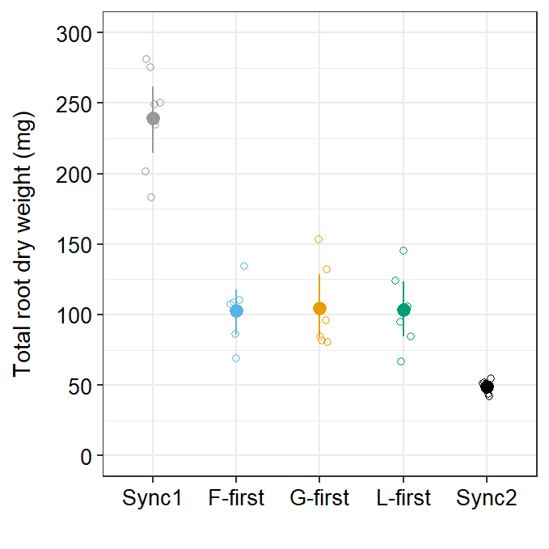

```r
root$Treatment<-factor(root$Treatment, levels=c("Sync1", "F-first", "G-first", "L-first", "Sync2"))
colors<-c("#999999", "#56B4E9", "#E69F00", "#009E73", "black")

root1<-vrd(x=RDW~Treatment, data=root, depth="maxDepth", replicate="Replicate", D=90)

(p3<-ggplot(root1, aes(x=Treatment, y=RDWtotal, color=Treatment)) +
      geom_jitter(shape=1, width=0.1) +
      labs(x = "", y = "Total root dry weight (mg)") +
      theme_bw()+
      stat_summary(fun.data="mean_cl_boot", size=0.5)+
      scale_color_manual(values=colors)+
      theme(legend.position = "none",
            axis.text=element_text(size=10, color="black"),
            axis.title.y = element_text(margin=margin(t=0,b=0,r=10,l=0)),
            axis.text.x=element_text(angle=0))+
      scale_y_continuous(limits=c(0,300), breaks=c(0,50,100,150,200,250,300)))
```

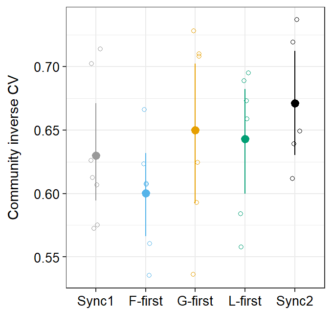

```r
(p<-ggplot(root1, aes(x=Treatment, y=invCV, color=Treatment)) +
      geom_jitter(shape=1, width=0.1) +
      labs(x = "", y = "Community inverse CV") +
      theme_bw()+
      stat_summary(fun.data="mean_cl_boot", size=0.5)+
      scale_color_manual(values=colors)+
      theme(legend.position = "none",
            axis.text=element_text(size=10, color="black"),
            axis.title.y = element_text(margin=margin(t=0,b=0,r=10,l=0)),
            axis.text.x=element_text(angle=0)))
```

```r
#ggsave("Total_root_productivity.tiff", p3, dpi=1000, compression="lzw", width=9, height=9, units="cm")
```

### Effect sizes

#### Total root productivity

```r
es.rdw<-bootstrap_ES(response="RDWtotal", data=root1, contr=c("F-first/G-first", "F-first/L-first", "G-first/L-first"), plot=FALSE)
knitr::kable(es.rdw$summary)
```

| Contrast | lowCI | ES | highCI | relES |
| --- | --- | --- | --- | --- |
| F-first/G-first | -31.02810 | -2.052667 | 24.24370 | -1.9604347 |
| F-first/L-first | -27.62605 | -0.832650 | 24.72523 | -0.8046121 |
| G-first/L-first | -28.74063 | 1.220017 | 32.09020 | 1.1789349 |

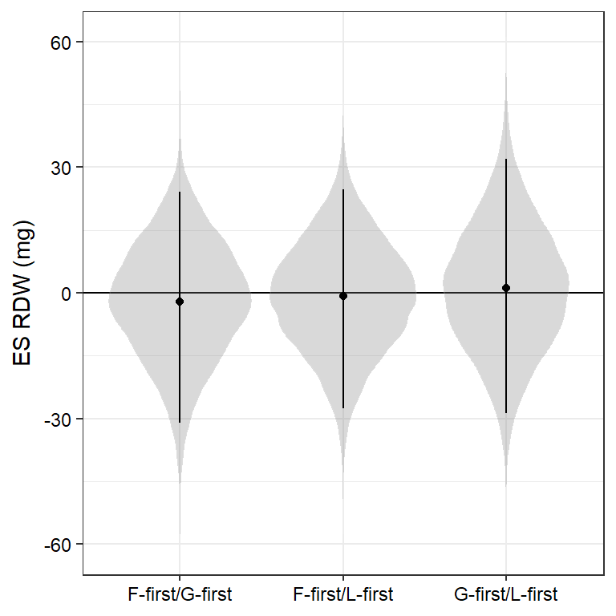

```r
ggplot(es.rdw$bootstrap)+
  geom_hline(yintercept = 0)+
  stat_ydensity(aes(x=Contrast, y=ES), fill="grey50", color=adjustcolor("white", alpha.f = 0.1), alpha=0.3)+
  geom_segment(data=es.rdw$summary, aes(x=Contrast, xend=Contrast, y=lowCI, yend=highCI), color="black", size=0.5)+
  geom_point(data=es.rdw$summary, aes(x=Contrast, y=ES), shape=16, color="black")+
  theme_bw()+
  xlab("")+
  ylab("ES RDW (mg)")+
  theme(axis.title=element_text(color="black", face="plain"),
  axis.title.y=element_text(margin = margin(t = 0, r = 5, b = 0, l = 0)),
  axis.title.x=element_blank(),
  axis.text=element_text(color="black"))
```

#### MRD biomass

```r
es.mrdb<-bootstrap_ES(response="MRD", data=root1, contr=c("F-first/G-first", "F-first/L-first", "G-first/L-first"), plot=FALSE)
knitr::kable(es.mrdb$summary)
```

| Contrast | lowCI | ES | highCI | relES |
| --- | --- | --- | --- | --- |
| F-first/G-first | 0.1718820 | 0.3980583 | 0.6330516 | 1.2652580 |
| F-first/L-first | -0.2695726 | 0.0896462 | 0.4362503 | 0.2821809 |
| G-first/L-first | -0.6664817 | -0.3084121 | 0.0230946 | -0.9707941 |

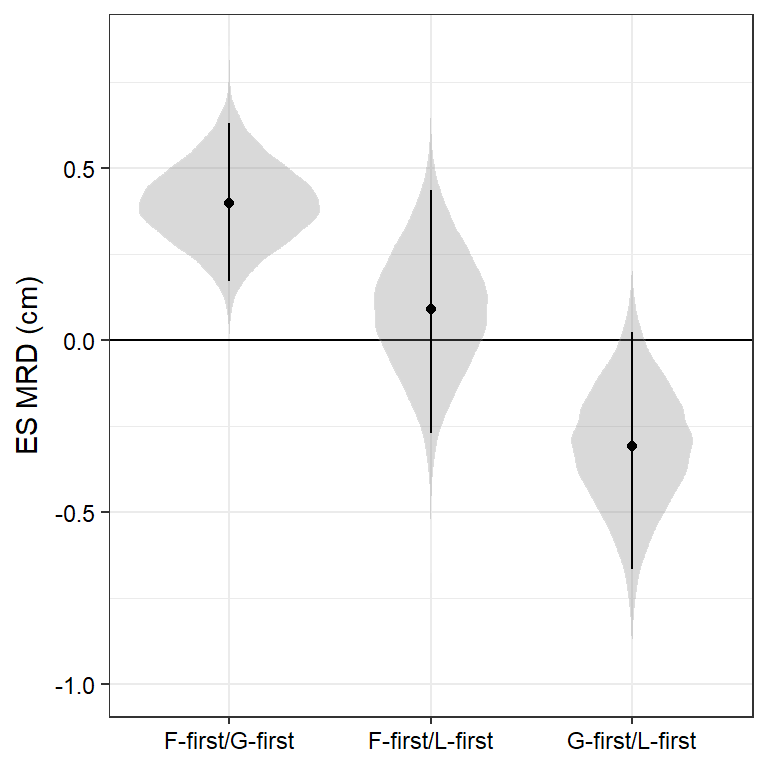

```r
ggplot(es.mrdb$bootstrap)+
  geom_hline(yintercept = 0)+
  stat_ydensity(aes(x=Contrast, y=ES), fill="grey50", color=adjustcolor("white", alpha.f = 0.1), alpha=0.3)+
  geom_segment(data=es.mrdb$summary, aes(x=Contrast, xend=Contrast, y=lowCI, yend=highCI), color="black", size=0.5)+
  geom_point(data=es.mrdb$summary, aes(x=Contrast, y=ES), shape=16, color="black")+
  theme_bw()+
  xlab("")+
  ylab("ES MRD (cm)")+
  theme(axis.title=element_text(color="black", face="plain"),
  axis.title.y=element_text(margin = margin(t = 0, r = 5, b = 0, l = 0)),
  axis.title.x=element_blank(),
  axis.text=element_text(color="black"))
```

### Plot root biomass distribution in soil layers

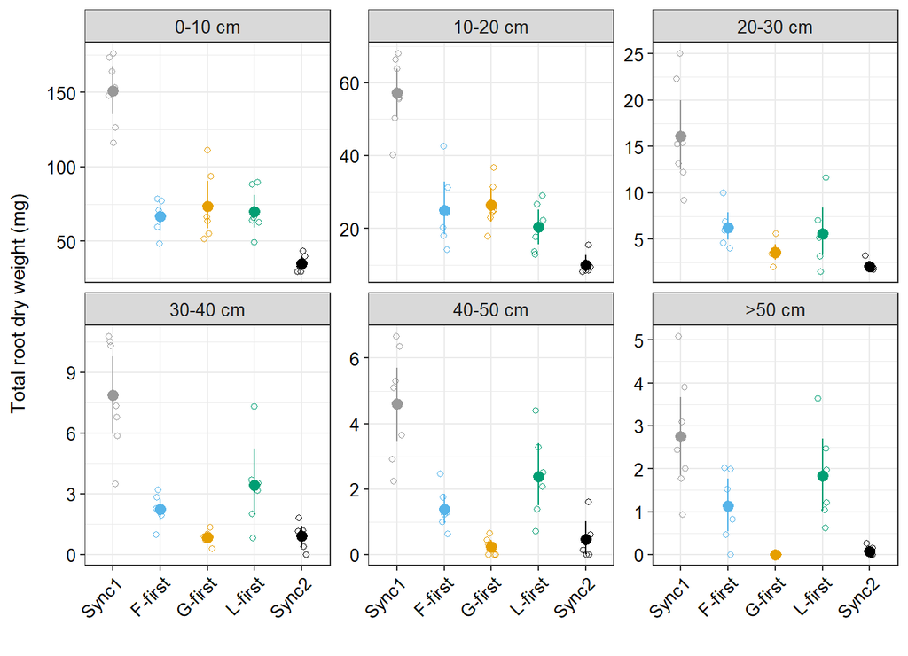

```r
supp.labs<-c("0-10 cm", "10-20 cm", "20-30 cm", "30-40 cm", "40-50 cm", ">50 cm")
names(supp.labs)<-c("0-10 cm", "10-20 cm", "20-30 cm", "30-40 cm", "40-50 cm", "50-60 cm")

(p4<-ggplot(root, aes(x=Treatment, y=RDW, color=Treatment)) +
    geom_jitter(shape=1, width=0.1) +
    labs(x = "", y = "Total root dry weight (mg)") +
    theme_bw()+
    stat_summary(fun.data="mean_cl_boot", size=0.5)+
    scale_color_manual(values=colors)+
    theme(legend.position = "none",
          axis.text=element_text(color="black"),
          axis.title.y = element_text(margin=margin(t=0,b=0,r=10,l=0)),
          axis.text.x=element_text(size=10, angle=45, hjust = 1, vjust=1),
          axis.text.y=element_text(size=10),
          strip.text = element_text(size=10))+
    facet_wrap(~Layer, scales="free_y",
               labeller=labeller(Layer=supp.labs)))
```

```r
#ggsave("FigureS3.tiff", p4, dpi=1000, compression="lzw", width=18, height=13, units="cm")
```

### Root biomass distribution in the soil

Because some layers did not contain any roots (RDW=0), we had zero-inflated continuous data ($Y \ge 0$). Data were analysed using a hurdle model combining a gamma GLMM and a Bernoulli GLMM (zero-altered gamma model or ZAG model). In a ZAG model, zeroes are generated by the binary part of the model (1 or 0). Non-zero data (that occur that roots are present in a layer) are modeled using a second (continuous) distribution (gamma in this case). The hurdle model was fitted according to Chapter 7 in Zuur and Ieno (2016) [Beginner’s guide to zero-inflated models with R](http://highstat.com/index.php/beginner-s-guide-to-zero-inflated-models). Highland Statistics Ltd.

#### Fit gamma component of hurdle model

```r
root$Depth<-root$maxDepth-5

root.pos<-subset(root, RDW>0) #Only select positive RDW values
root.pos$Rz<-factor(root.pos$Rz)

#Fit GLMM with gamma distribution
H1<-glmmPQL(fixed=RDW~Depth*Treatment, random=~1|Rz, data=root.pos, family=Gamma(link="log"))
summary(H1)
```

```
## Linear mixed-effects model fit by maximum likelihood
##   Data: root.pos
##   AIC BIC logLik
##    NA  NA     NA
##
## Random effects:
##  Formula: ~1 | Rz
##         (Intercept)  Residual
## StdDev:   0.2093552 0.4739855
##
## Variance function:
##  Structure: fixed weights
##  Formula: ~invwt
## Fixed effects:  RDW ~ Depth * Treatment
##                            Value  Std.Error  DF    t-value p-value
## (Intercept)             5.198650 0.17303757 129  30.043473  0.0000
## Depth                  -0.081493 0.00441935 129 -18.440053  0.0000
## TreatmentF-first       -0.882303 0.25577033  25  -3.449592  0.0020
## TreatmentG-first       -0.158325 0.27088042  25  -0.584484  0.5641
## TreatmentL-first       -1.024877 0.25470441  25  -4.023791  0.0005
## TreatmentSync2         -1.357011 0.27549528  25  -4.925712  0.0000
## Depth:TreatmentF-first -0.001688 0.00662837 129  -0.254618  0.7994
## Depth:TreatmentG-first -0.058010 0.00846542 129  -6.852566  0.0000
## Depth:TreatmentL-first  0.007769 0.00650511 129   1.194263  0.2346
## Depth:TreatmentSync2   -0.020982 0.00789831 129  -2.656462  0.0089
##  Correlation:
##                        (Intr) Depth  TrtmF- TrtmG- TrtmL- TrtmS2 Dp:TF- Dp:TG-
## Depth                  -0.766
## TreatmentF-first       -0.677  0.518
## TreatmentG-first       -0.639  0.489  0.432
## TreatmentL-first       -0.679  0.521  0.460  0.434
## TreatmentSync2         -0.628  0.481  0.425  0.401  0.427
## Depth:TreatmentF-first  0.511 -0.667 -0.766 -0.326 -0.347 -0.321
## Depth:TreatmentG-first  0.400 -0.522 -0.271 -0.770 -0.272 -0.251  0.348
## Depth:TreatmentL-first  0.521 -0.679 -0.352 -0.333 -0.766 -0.327  0.453  0.355
## Depth:TreatmentSync2    0.429 -0.560 -0.290 -0.274 -0.291 -0.758  0.373  0.292
##                        Dp:TL-
## Depth
## TreatmentF-first
## TreatmentG-first
## TreatmentL-first
## TreatmentSync2
## Depth:TreatmentF-first
## Depth:TreatmentG-first
## Depth:TreatmentL-first
## Depth:TreatmentSync2    0.380
##
## Standardized Within-Group Residuals:
##         Min          Q1         Med          Q3         Max
## -1.66689033 -0.75461721 -0.09996008  0.55289496  3.64472676
##
## Number of Observations: 164
## Number of Groups: 30
```

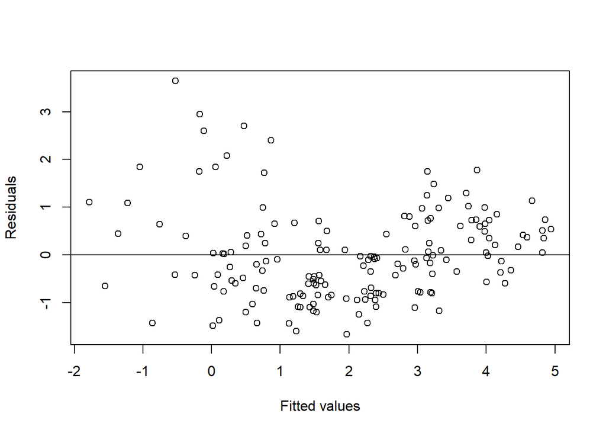

```r
#Model validation
E1<-resid(H1, type="pearson")
F1<-fitted(H1, type="response")
plot(F1, E1, xlab="Fitted values", ylab="Residuals"); abline(h=0)
```

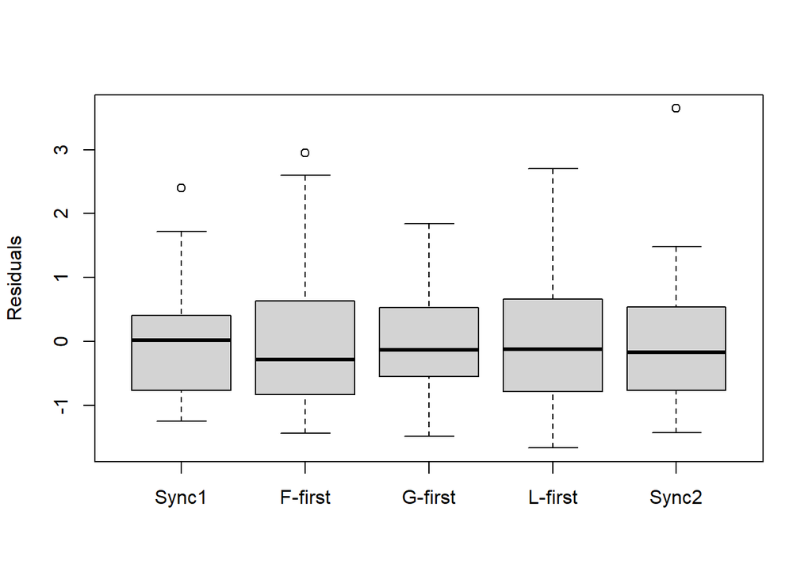

```r
boxplot(E1~root.pos$Treatment, xlab="", ylab="Residuals")
```

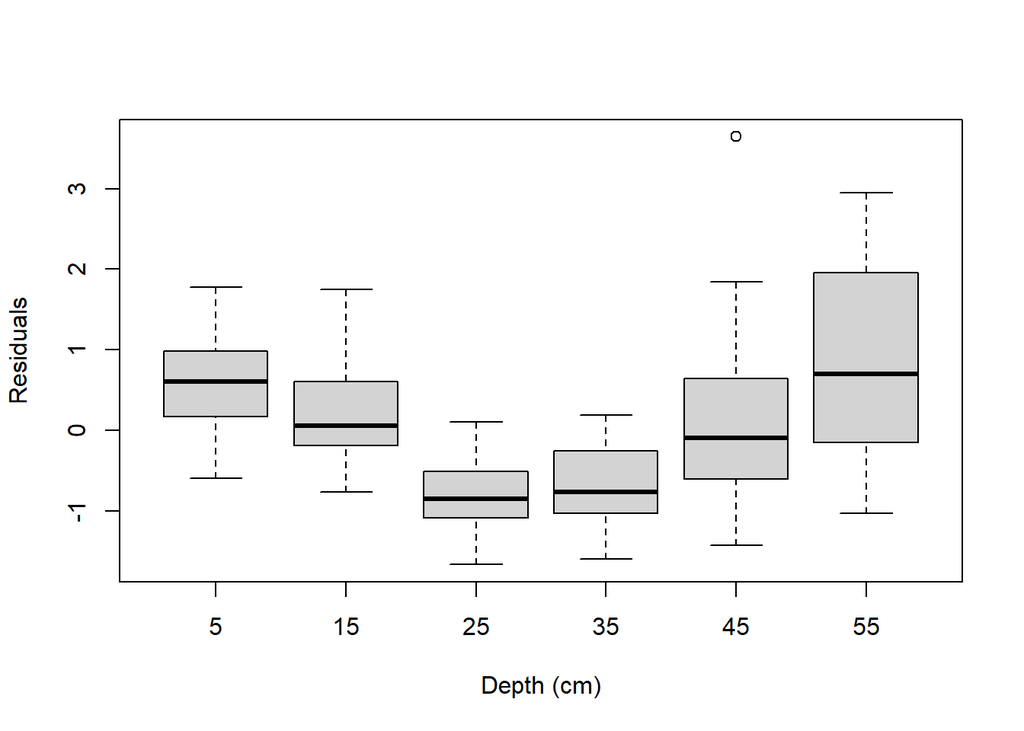

```r
boxplot(E1~root.pos$Depth, xlab="Depth (cm)", ylab="Residuals")
```

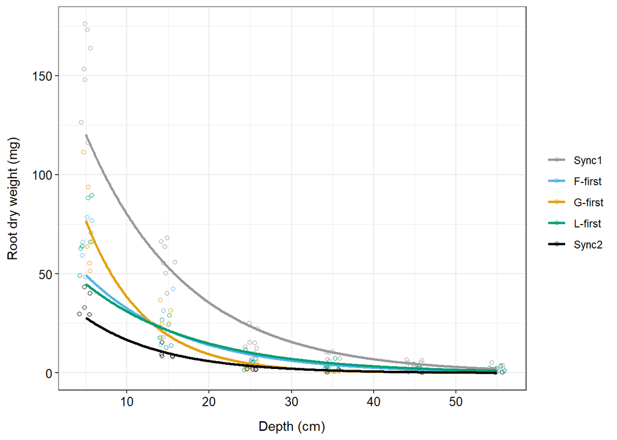

```r
#Make predictions
pred.mm.H1 <- data.frame(Depth=rep(seq(5,55,by=0.1), 5), Treatment=rep(unique(root$Treatment), each=501))
pred.mm.H1$Pred <- predict(H1, newdata=pred.mm.H1, type="response", level=0)

#Plot GLMM fit
(p5<-ggplot(pred.mm.H1) +
    geom_jitter(data=root.pos, aes(x=Depth, y=RDW, colour=Treatment), width=1, shape=1) +
    geom_line(aes(x = Depth, y = Pred, color=Treatment), size=1) +
    ylab("Root dry weight (mg)")+
    xlab("Depth (cm)")+
    theme_bw()+
    theme(legend.title=element_blank(),
          axis.text=element_text(size=10, color="black"),
          axis.title.y = element_text(margin=margin(r=10)),
          axis.title.x = element_text(margin=margin(t=10)))+
    scale_color_manual(values=colors))
```

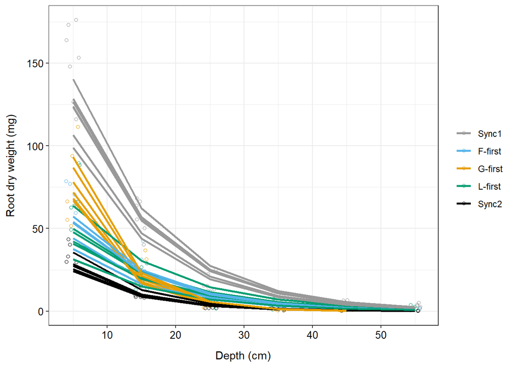

```r
#Plot GLMM fit
#One curve for each rhizobox
(p6<-ggplot(root.pos) +
    geom_jitter(aes(x=Depth, y=RDW, colour=Treatment), width=1, shape=1) +
    geom_line(data=cbind(root.pos, Pred=predict(H1, type="response")), aes(x = Depth, y = Pred, color=Treatment, group=Rz), size=1) +
    ylab("Root dry weight (mg)")+
    xlab("Depth (cm)")+
    theme_bw()+
    theme(legend.title=element_blank(),
          axis.text=element_text(size=10, color="black"),
          axis.title.y = element_text(margin=margin(r=10)),
          axis.title.x = element_text(margin=margin(t=10)))+
    scale_color_manual(values=colors))
```

#### Fit binomial component of hurdle model

```r
root$RDW.01<-as.numeric(root$RDW > 0)
root$Rz<-factor(root$Rz)
root$sDepth<-scale(root$Depth, center=TRUE, scale=TRUE)

#Fit GLMM with a binomial distribution
H2<-glmmPQL(fixed=RDW.01~Depth*Treatment, random=~1|Rz, data=root, family=binomial(link="logit"))
summary(H2)
```

```
## Linear mixed-effects model fit by maximum likelihood
##   Data: root
##   AIC BIC logLik
##    NA  NA     NA
##
## Random effects:
##  Formula: ~1 | Rz
##         (Intercept)    Residual
## StdDev:    13.93088 4.11976e-06
##
## Variance function:
##  Structure: fixed weights
##  Formula: ~invwt
## Fixed effects:  RDW.01 ~ Depth * Treatment
##                            Value Std.Error  DF    t-value p-value
## (Intercept)             32.56637  88.89578 145  0.3663433  0.7146
## Depth                    0.00000   2.57037 145 -0.0000008  1.0000
## TreatmentF-first       171.22284  89.10695  25  1.9215431  0.0661
## TreatmentG-first       144.23931  89.31717  25  1.6149113  0.1189
## TreatmentL-first         0.00000 130.85104  25  0.0000000  1.0000
## TreatmentSync2          50.56918  89.12663  25  0.5673857  0.5755
## Depth:TreatmentF-first  -3.56375   2.57058 145 -1.3863592  0.1678
## Depth:TreatmentG-first  -3.92901   2.57429 145 -1.5262506  0.1291
## Depth:TreatmentL-first   0.00000   3.78348 145  0.0000000  1.0000
## Depth:TreatmentSync2    -1.72216   2.57037 145 -0.6700049  0.5039
##  Correlation:
##                        (Intr) Depth  TrtmF- TrtmG- TrtmL- TrtmS2 Dp:TF- Dp:TG-
## Depth                  -0.867
## TreatmentF-first       -0.998  0.865
## TreatmentG-first       -0.995  0.863  0.993
## TreatmentL-first       -0.679  0.589  0.678  0.676
## TreatmentSync2         -0.997  0.865  0.995  0.993  0.678
## Depth:TreatmentF-first  0.867 -1.000 -0.866 -0.863 -0.589 -0.865
## Depth:TreatmentG-first  0.866 -0.998 -0.864 -0.866 -0.588 -0.864  0.998
## Depth:TreatmentL-first  0.589 -0.679 -0.588 -0.587 -0.867 -0.588  0.679  0.678
## Depth:TreatmentSync2    0.867 -1.000 -0.865 -0.863 -0.589 -0.865  1.000  0.998
##                        Dp:TL-
## Depth
## TreatmentF-first
## TreatmentG-first
## TreatmentL-first
## TreatmentSync2
## Depth:TreatmentF-first
## Depth:TreatmentG-first
## Depth:TreatmentL-first
## Depth:TreatmentSync2    0.679
##
## Standardized Within-Group Residuals:
##           Min            Q1           Med            Q3           Max
## -5.660781e+00 -1.447565e-02 -6.094571e-13  2.467230e-15  5.230954e+00
##
## Number of Observations: 180
## Number of Groups: 30
```

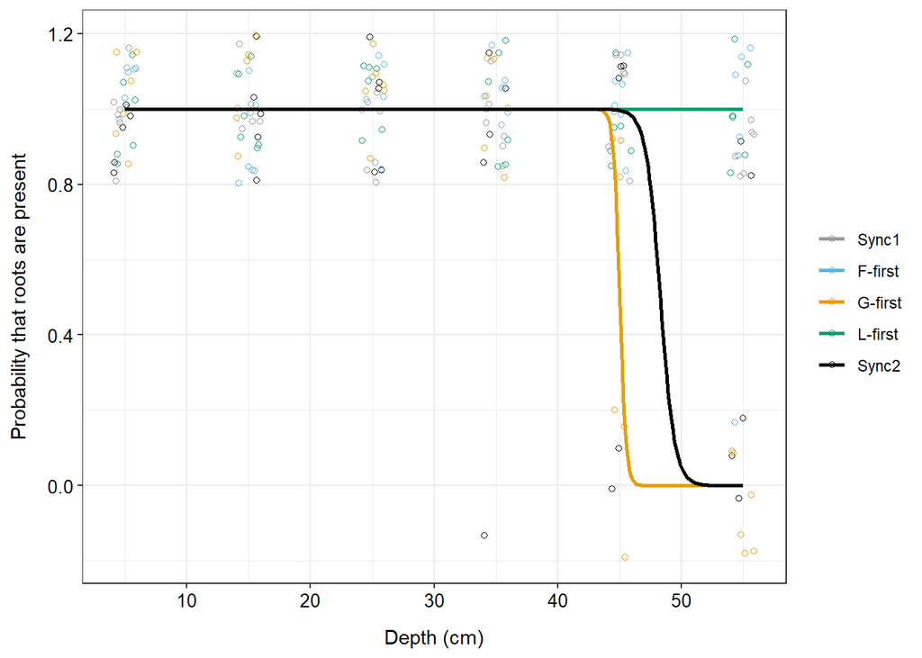

```r
#Make predictions
pred.mm.H2 <- data.frame(Depth=rep(seq(5,55,by=0.1), 5),
                      Treatment=rep(unique(root$Treatment), each=501))
pred.mm.H2$Pred <- predict(H2, newdata=pred.mm.H2, type="response", level=0)

#Plot binomial fit
(p7<-ggplot(pred.mm.H2) +
    geom_jitter(data=root, aes(x=Depth, y=RDW.01, colour=Treatment), height=0.2, width=1, shape=1) +
    geom_line(aes(x = Depth, y = Pred, color=Treatment), size=1) +
    ylab("Probability that roots are present")+
    xlab("Depth (cm)")+
    theme_bw()+
    theme(legend.title=element_blank(),
          axis.text=element_text(size=10, color="black"),
          axis.title.y = element_text(margin=margin(r=10)),
          axis.title.x = element_text(margin=margin(t=10)))+
    scale_color_manual(values=colors))
```

#### Merge gamma and binomial components

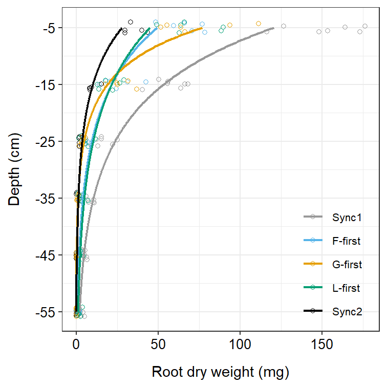

```r
beta<-fixef(H1) #Extract regression coefficients of Gamma GLMM
gamma<-fixef(H2) #Extract regression coefficients of Binomial GLMM

#Create new data for predictions
newdata <- expand.grid(Depth = seq(5, 55, by = 0.1),
                       Treatment = levels(root$Treatment))

X<-model.matrix(~Depth*Treatment, data=newdata)

mu <- exp(X %*% beta)
Pi  <- exp(X %*% gamma) / (1 + exp(X %*% gamma))

#Get predictions for Hurdle model
newdata$PredZAG<-Pi * mu

#Plot hurdle model fit
(p8<-ggplot(root) +
    geom_jitter(data=root, aes(x=-Depth, y=RDW, colour=Treatment), width=1, shape=1) +
    geom_line(data=newdata, aes(x = -Depth, y = PredZAG, color=Treatment), size=0.8) +
    ylab("Root dry weight (mg)")+
    xlab("Depth (cm)")+
    theme_bw()+
    theme(legend.title=element_blank(),
          legend.position=c(0.85,0.22),
          legend.text=element_text(size=8),
          legend.background = element_blank(),
          legend.key = element_blank(),
          axis.text=element_text(size=10, color="black"),
          axis.title.y = element_text(margin=margin(r=10)),
          axis.title.x = element_text(margin=margin(t=10)))+
    scale_x_continuous(breaks=c(-5,-15,-25,-35,-45,-55))+
    scale_color_manual(values=colors)+
    coord_flip())
```

```r
#ggsave("Figure4.tiff", p8, dpi=1000, compression="lzw", width=9.5, height=10, units="cm")
```

#### Create figure showing model fits for the Gamma and Binomial components of the hurdle model

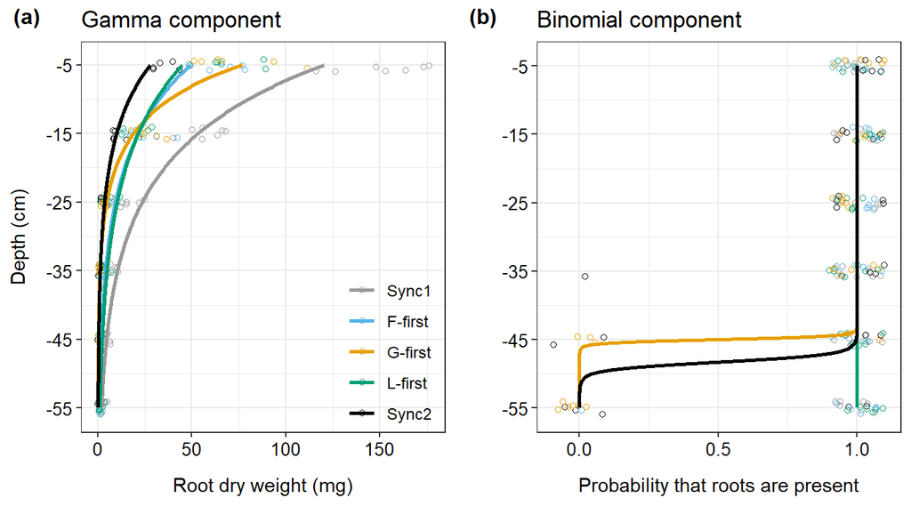

```r
#Plot gamma component
p5<-ggplot(pred.mm.H1) +
    geom_jitter(data=root.pos, aes(x=-Depth, y=RDW, colour=Treatment), width=1, shape=1) +
    geom_line(aes(x = -Depth, y = Pred, color=Treatment), size=1) +
    ylab("Root dry weight (mg)")+
    xlab("Depth (cm)")+
    theme_bw()+
    theme(legend.title=element_blank(),
          legend.position=c(0.85,0.22),
          legend.text=element_text(size=9),
          legend.background = element_blank(),
          legend.key = element_blank(),
          axis.text=element_text(size=10, color="black"),
          axis.title.y = element_text(margin=margin(r=10)),
          axis.title.x = element_text(margin=margin(t=10)))+
    scale_color_manual(values=colors)+
    coord_flip()+
    scale_x_continuous(breaks=c(-5,-15,-25,-35,-45,-55))+
    ggtitle("Gamma component")

#Plot binomial component
p7<-ggplot(pred.mm.H2) +
    geom_jitter(data=root, aes(x=-Depth, y=RDW.01, colour=Treatment), height=0.1, width=1, shape=1) +
    geom_line(aes(x = -Depth, y = Pred, color=Treatment), size=1) +
    ylab("Probability that roots are present")+
    xlab("")+
    theme_bw()+
    theme(legend.position="none",
          axis.text=element_text(size=10, color="black"),
          axis.title.y = element_text(margin=margin(r=10)),
          axis.title.x = element_text(margin=margin(t=10)))+
    scale_color_manual(values=colors)+
    coord_flip()+
    scale_x_continuous(breaks=c(-5,-15,-25,-35,-45,-55))+
    scale_y_continuous(breaks=c(0,0.5,1))+
    ggtitle("Binomial component")

(p5and7<-ggarrange(p5, p7, nrow=1, ncol=2, labels=c("(a)", "(b)"), font.label = list(size=12)))
```

```r
#ggsave("FigureS2.tiff", p5and7, dpi=1000, compression="lzw", width=18, height=10, units="cm")
```

## Analysis of root distribution over time

### Load RootPainter data

```r
root.depth <- read.csv("Z:/Poem/Rhizoboxes/Backup_RootPainter/drive_rp_sync/projects/PE_rhizotrons_2017_1/results/segmentations/results.csv")

root.length <- read.csv("Z:/Poem/Rhizoboxes/Backup_RootPainter/drive_rp_sync/projects/PE_rhizotrons_2017_1/results/analysis_RVE/features.csv")

ID <- read.delim("Z:/Poem/Rhizoboxes/0_Rz_experiment_data/Data/Image_RZ.txt")
TIME <- read.delim("Z:/Poem/Rhizoboxes/0_Rz_experiment_data/Data/Date_TimePoint.txt")

filenames<-sapply(str_split(as.character(root.depth$image), pattern="-"), function(x){return(x[5])})
filenames<-as.numeric(sapply(str_split(filenames, pattern="\\."), function(x){return(x[1])}))

root.depth$Date<-sapply(str_split(as.character(root.depth$image), pattern="-"), function(x){
  return(paste(x[1], x[2], x[3], sep="-"))})

root.depth$imageID<-filenames
root.depth$Rz<-ID$RZ[match(filenames, ID$Image)]
root.depth$Time<-TIME$Day[match(root.depth$Date, TIME$Date)]

root.depth<-root.depth[order(root.depth$Rz, root.depth$Time),]

#Add treatment column
root.depth$Treatment<-root1$Treatment[match(root.depth$Rz, root1$Rz)]

#Add root_length column in root.depth
root.depth$root_length<-root.length$Total.Root.Length.mm[match(root.depth$image, root.length$File.Name)]
root.depth$root_length[is.na(root.depth$root_length)==T]<-0 #Replace NA values by zero
root.depth$root_length<-root.depth$root_length/1000 #Express results in meters

#Set Sync2 to zero before the second sowing
root.depth$mrd[which(root.depth$Treatment=="Sync2" & root.depth$Time<=9)]<-0
root.depth$maxrd[which(root.depth$Treatment=="Sync2" & root.depth$Time<=9)]<-0
root.depth$root_length[which(root.depth$Treatment=="Sync2" & root.depth$Time<=9)]<-0

#Remove rhizoboxes 35, 70, 15, 27, 137
root.depth<-root.depth[-which(root.depth$Rz==35|root.depth$Rz==70|root.depth$Rz==15|root.depth$Rz==27|root.depth$Rz==137),]

root.depth$Treatment<-factor(root.depth$Treatment, levels=c("Sync1", "F-first", "G-first", "L-first", "Sync2"))

#No root in image "2017-08-16-RZ-0001.png", so set mrd and maxrd to zero
root.depth$mrd[root.depth$image=="2017-08-16-RZ-0001.png"]<-0
root.depth$maxrd[root.depth$image=="2017-08-16-RZ-0001.png"]<-0
root.depth$root_length[root.depth$image=="2017-08-16-RZ-0001.png"]<-0
```

### Plot mean rooting depth over time

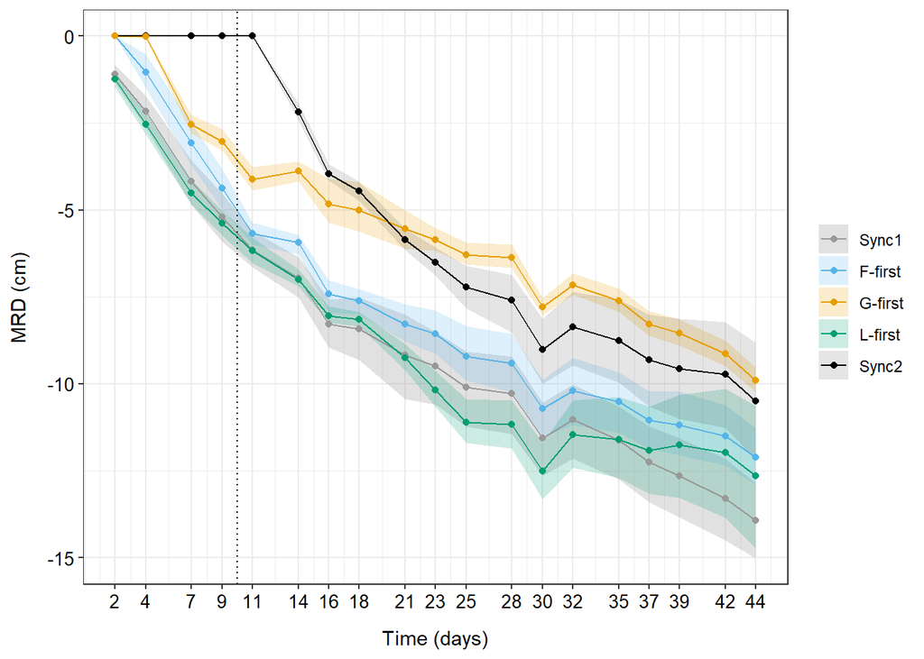

```r
#Create empty dataset for summary statistics
stat.mrd<-data.frame(Treatment=rep(NA, length(unique(root.depth$Rz))),
                     Time=rep(NA, length(unique(root.depth$Rz))),
                     meanValue=rep(NA, length(unique(root.depth$Rz))),
                     lower=rep(NA, length(unique(root.depth$Rz))),
                     upper=rep(NA, length(unique(root.depth$Rz))))

k<-0

for (i in unique(root.depth$Treatment)){

  for (j in unique(root.depth$Time)){

    k<-k+1
    sub<-root.depth[root.depth$Treatment==i & root.depth$Time==j,]
    #Calculate compatibility interval (bootstrap resampling)
    set.seed(1)
    a<-smean.cl.boot(sub$mrd, B=10000)
    stat.mrd[k,]<-c(i, j, as.numeric(a))}}

stat.mrd[,2]<-as.numeric(stat.mrd[,2])
stat.mrd[,3]<-as.numeric(stat.mrd[,3])
stat.mrd[,4]<-as.numeric(stat.mrd[,4])
stat.mrd[,5]<-as.numeric(stat.mrd[,5])

stat.mrd$Treatment<-factor(stat.mrd$Treatment, levels=c("Sync1", "F-first", "G-first", "L-first", "Sync2"))

#Plot mean rooting depth over time
(p9<-ggplot(stat.mrd, aes(x=Time, y=meanValue, color=Treatment))+
  geom_ribbon(aes(ymin=lower, ymax=upper, fill=Treatment, alpha=Treatment), color=NA)+
  geom_line()+
  geom_point(shape=16)+
  geom_vline(xintercept=10, linetype=3)+
  theme_bw()+
  theme(legend.title=element_blank(),
        axis.text=element_text(size=10, color="black"),
        axis.title.y = element_text(margin=margin(r=10)),
        axis.title.x = element_text(margin=margin(t=10)))+
  ylab("MRD (cm)")+
  xlab("Time (days)")+
  scale_color_manual(values=colors)+
  scale_fill_manual(values=colors)+
  scale_x_continuous(breaks=unique(stat.mrd$Time))+
  scale_alpha_manual(values=c(0.3,0.2,0.2,0.2,0.1)))
```

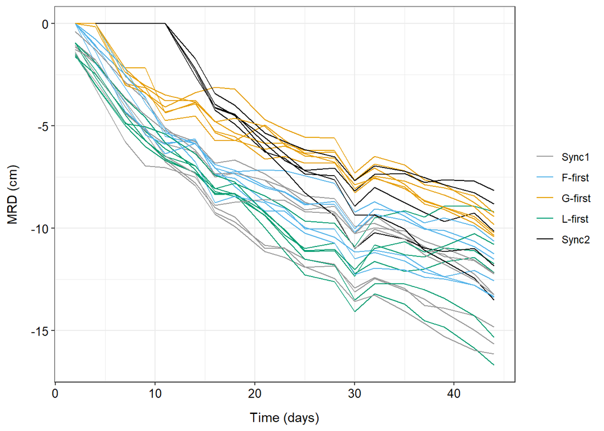

```r
#Plot mean rooting depth over time
#One line per rhizobox
(p10<-ggplot(root.depth, aes(x=Time, y=mrd, color=Treatment, group=Rz))+
  geom_line()+
  theme_bw()+
  theme(legend.title=element_blank(),
        axis.text=element_text(size=10, color="black"),
        axis.title.y = element_text(margin=margin(r=10)),
        axis.title.x = element_text(margin=margin(t=10)))+
  ylab("MRD (cm)")+
  xlab("Time (days)")+
  scale_color_manual(values=colors)+
  scale_fill_manual(values=colors))
```

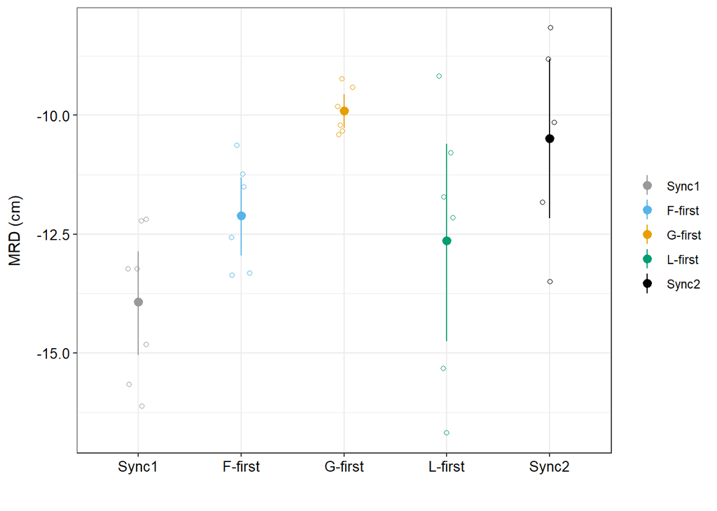

```r
#Plot mean rooting depth at last observation date

(p11<-ggplot(root.depth[root.depth$Time==44,], aes(x=Treatment, y=mrd, colour=Treatment)) +
    geom_jitter(width=0.1, shape=1) +
    stat_summary(fun.data="mean_cl_boot")+
    ylab("MRD (cm)")+
    xlab("")+
    theme_bw()+
    scale_color_manual(values=colors)+
    theme(legend.title=element_blank(),
          axis.text=element_text(size=10, color="black"),
          axis.title.y = element_text(margin=margin(r=10)),
          axis.title.x = element_text(margin=margin(t=10))))
```

```r
model<-glm(-mrd~Treatment, root.depth[root.depth$Time==44,], family=Gamma(link="log"))

summary(model)
```

```
##
## Call:
## glm(formula = -mrd ~ Treatment, family = Gamma(link = "log"),
##     data = root.depth[root.depth$Time == 44, ])
##
## Deviance Residuals:
##      Min        1Q    Median        3Q       Max
## -0.30397  -0.07424  -0.03563   0.08884   0.29066
##
## Coefficients:
##                  Estimate Std. Error t value Pr(>|t|)
## (Intercept)       2.63376    0.05666  46.480  < 2e-16 ***
## TreatmentF-first -0.14001    0.08341  -1.679 0.105678
## TreatmentG-first -0.34098    0.08341  -4.088 0.000395 ***
## TreatmentL-first -0.09670    0.08341  -1.159 0.257284
## TreatmentSync2   -0.28306    0.08778  -3.224 0.003499 **
## ---
## Signif. codes:  0 '***' 0.001 '**' 0.01 '*' 0.05 '.' 0.1 ' ' 1
##
## (Dispersion parameter for Gamma family taken to be 0.02247635)
##
##     Null deviance: 1.02944  on 29  degrees of freedom
## Residual deviance: 0.55623  on 25  degrees of freedom
## AIC: 125.3
##
## Number of Fisher Scoring iterations: 4
```

```r
summary(emmeans(model, "Treatment", contr="tukey"), type="response")
```

```
## $emmeans
##  Treatment response    SE  df asymp.LCL asymp.UCL
##  Sync1         13.9 0.789 Inf     12.46      15.6
##  F-first       12.1 0.741 Inf     10.74      13.6
##  G-first        9.9 0.606 Inf      8.78      11.2
##  L-first       12.6 0.774 Inf     11.21      14.3
##  Sync2         10.5 0.704 Inf      9.20      12.0
##
## Confidence level used: 0.95
## Intervals are back-transformed from the log scale
##
## $contrasts
##  contrast              ratio     SE  df z.ratio p.value
##  Sync1 / (F-first)     1.150 0.0959 Inf  1.679  0.4472
##  Sync1 / (G-first)     1.406 0.1173 Inf  4.088  0.0004
##  Sync1 / (L-first)     1.102 0.0919 Inf  1.159  0.7746
##  Sync1 / Sync2         1.327 0.1165 Inf  3.224  0.0111
##  (F-first) / (G-first) 1.223 0.1058 Inf  2.322  0.1379
##  (F-first) / (L-first) 0.958 0.0829 Inf -0.500  0.9873
##  (F-first) / Sync2     1.154 0.1047 Inf  1.576  0.5130
##  (G-first) / (L-first) 0.783 0.0678 Inf -2.822  0.0384
##  (G-first) / Sync2     0.944 0.0857 Inf -0.638  0.9689
##  (L-first) / Sync2     1.205 0.1094 Inf  2.053  0.2409
##
## P value adjustment: tukey method for comparing a family of 5 estimates
## Tests are performed on the log scale
```

```r
summary(emmeans(model, "Treatment", contr="tukey"))
```

```
## $emmeans
##  Treatment emmean     SE  df asymp.LCL asymp.UCL
##  Sync1       2.63 0.0567 Inf      2.52      2.74
##  F-first     2.49 0.0612 Inf      2.37      2.61
##  G-first     2.29 0.0612 Inf      2.17      2.41
##  L-first     2.54 0.0612 Inf      2.42      2.66
##  Sync2       2.35 0.0670 Inf      2.22      2.48
##
## Results are given on the log (not the response) scale.
## Confidence level used: 0.95
##
## $contrasts
##  contrast              estimate     SE  df z.ratio p.value
##  Sync1 - (F-first)       0.1400 0.0834 Inf  1.679  0.4472
##  Sync1 - (G-first)       0.3410 0.0834 Inf  4.088  0.0004
##  Sync1 - (L-first)       0.0967 0.0834 Inf  1.159  0.7746
##  Sync1 - Sync2           0.2831 0.0878 Inf  3.224  0.0111
##  (F-first) - (G-first)   0.2010 0.0866 Inf  2.322  0.1379
##  (F-first) - (L-first)  -0.0433 0.0866 Inf -0.500  0.9873
##  (F-first) - Sync2       0.1430 0.0908 Inf  1.576  0.5130
##  (G-first) - (L-first)  -0.2443 0.0866 Inf -2.822  0.0384
##  (G-first) - Sync2      -0.0579 0.0908 Inf -0.638  0.9689
##  (L-first) - Sync2       0.1864 0.0908 Inf  2.053  0.2409
##
## Results are given on the log (not the response) scale.
## P value adjustment: tukey method for comparing a family of 5 estimates
```

### Plot maximum rooting depth over time

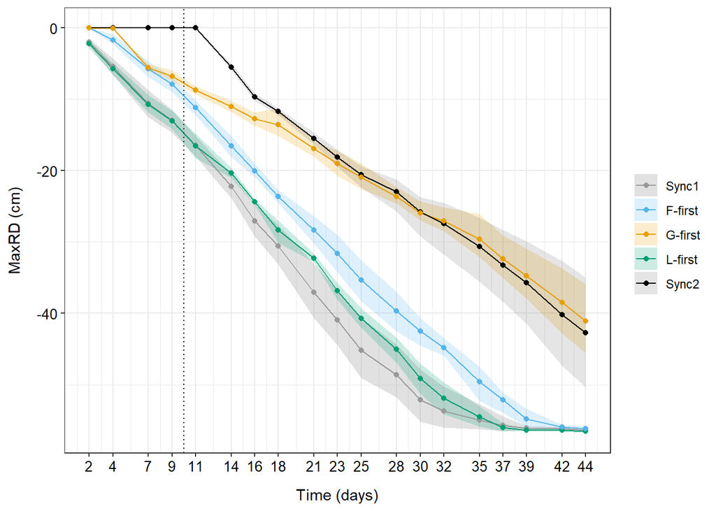

```r
#Create empty dataset for summary statistics
stat.maxrd<-data.frame(Treatment=rep(NA, length(unique(root.depth$Rz))),
                       Time=rep(NA, length(unique(root.depth$Rz))),
                       meanValue=rep(NA, length(unique(root.depth$Rz))),
                       lower=rep(NA, length(unique(root.depth$Rz))),
                       upper=rep(NA, length(unique(root.depth$Rz))))

k<-0

for (i in unique(root.depth$Treatment)){

  for (j in unique(root.depth$Time)){

    k<-k+1
    sub<-root.depth[root.depth$Treatment==i & root.depth$Time==j,]
    #Calculate compatibility interval (bootstrap resampling)
    set.seed(1)
    a<-smean.cl.boot(sub$maxrd, B=10000)
    stat.maxrd[k,]<-c(i, j, as.numeric(a))}}

stat.maxrd[,2]<-as.numeric(stat.maxrd[,2])
stat.maxrd[,3]<-as.numeric(stat.maxrd[,3])
stat.maxrd[,4]<-as.numeric(stat.maxrd[,4])
stat.maxrd[,5]<-as.numeric(stat.maxrd[,5])

stat.maxrd$Treatment<-factor(stat.maxrd$Treatment, levels=c("Sync1", "F-first", "G-first", "L-first", "Sync2"))

#Plot max rooting depth over time
(p9a<-ggplot(stat.maxrd, aes(x=Time, y=meanValue, color=Treatment))+
  geom_ribbon(aes(ymin=lower, ymax=upper, fill=Treatment, alpha=Treatment), color=NA)+
  geom_line()+
  geom_point(shape=16)+
  geom_vline(xintercept=10, linetype=3)+
  theme_bw()+
  theme(legend.title=element_blank(),
        axis.text=element_text(size=10, color="black"),
        axis.title.y = element_text(margin=margin(r=10)),
        axis.title.x = element_text(margin=margin(t=10)))+
  ylab("MaxRD (cm)")+
  xlab("Time (days)")+
  scale_color_manual(values=colors)+
  scale_fill_manual(values=colors)+
  scale_x_continuous(breaks=unique(stat.maxrd$Time))+
  scale_alpha_manual(values=c(0.3,0.2,0.2,0.2,0.1)))
```

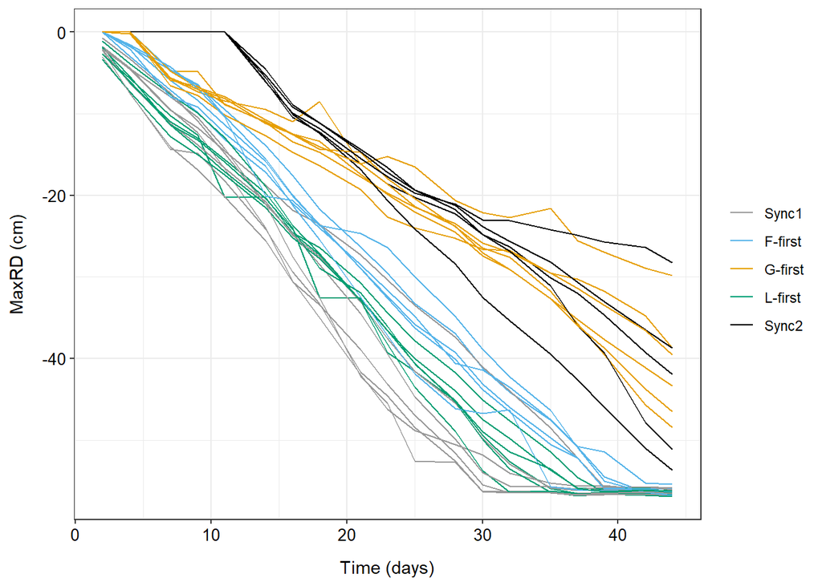

```r
#Plot max rooting depth over time
#One line per rhizobox
(p10a<-ggplot(root.depth, aes(x=Time, y=maxrd, color=Treatment, group=Rz))+
  geom_line()+
  theme_bw()+
  theme(legend.title=element_blank(),
        axis.text=element_text(size=10, color="black"),
        axis.title.y = element_text(margin=margin(r=10)),
        axis.title.x = element_text(margin=margin(t=10)))+
  ylab("MaxRD (cm)")+
  xlab("Time (days)")+
  scale_color_manual(values=colors)+
  scale_fill_manual(values=colors))
```

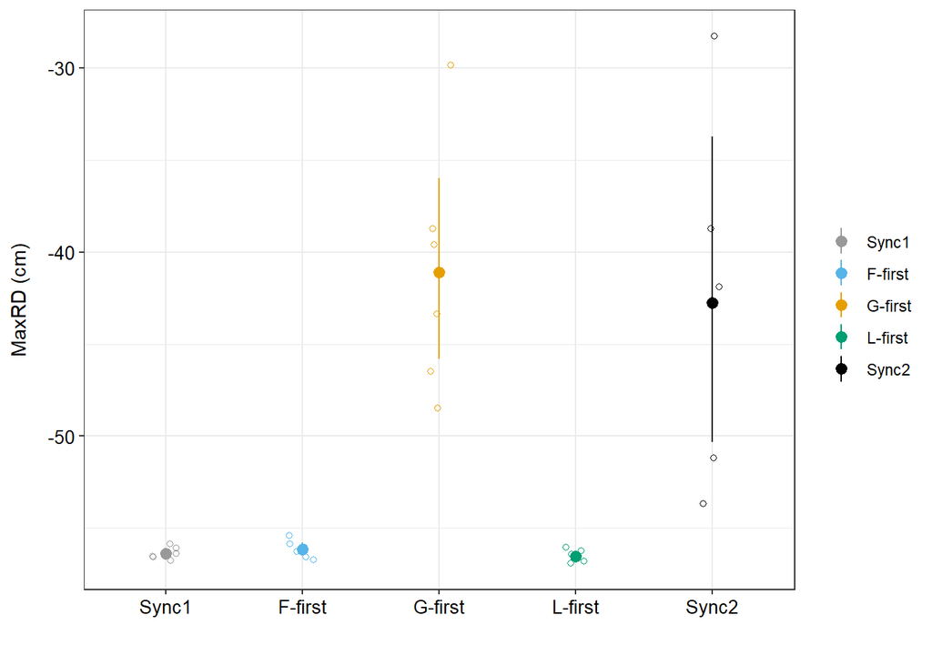

```r
#Plot max rooting depth at last observation date

(p11a<-ggplot(root.depth[root.depth$Time==44,], aes(x=Treatment, y=maxrd, colour=Treatment)) +
    geom_jitter(width=0.1, shape=1) +
    stat_summary(fun.data="mean_cl_boot")+
    ylab("MaxRD (cm)")+
    xlab("")+
    theme_bw()+
    scale_color_manual(values=colors)+
    theme(legend.title=element_blank(),
          axis.text=element_text(size=10, color="black"),
          axis.title.y = element_text(margin=margin(r=10)),
          axis.title.x = element_text(margin=margin(t=10))))
```

```r
model<-glm(-maxrd~Treatment, root.depth[root.depth$Time==44,], family=Gamma(link="log"))

summary(model)
```

```
##
## Call:
## glm(formula = -maxrd ~ Treatment, family = Gamma(link = "log"),
##     data = root.depth[root.depth$Time == 44, ])
##
## Deviance Residuals:
##      Min        1Q    Median        3Q       Max
## -0.38670  -0.00907   0.00077   0.00693   0.23612
##
## Coefficients:
##                   Estimate Std. Error t value Pr(>|t|)
## (Intercept)       4.031978   0.045387  88.835  < 2e-16 ***
## TreatmentF-first -0.004098   0.066808  -0.061 0.951579
## TreatmentG-first -0.316227   0.066808  -4.733 7.44e-05 ***
## TreatmentL-first  0.002611   0.066808   0.039 0.969130
## TreatmentSync2   -0.276628   0.070313  -3.934 0.000587 ***
## ---
## Signif. codes:  0 '***' 0.001 '**' 0.01 '*' 0.05 '.' 0.1 ' ' 1
##
## (Dispersion parameter for Gamma family taken to be 0.0144199)
##
##     Null deviance: 0.99804  on 29  degrees of freedom
## Residual deviance: 0.39472  on 25  degrees of freedom
## AIC: 202.22
##
## Number of Fisher Scoring iterations: 4
```

```r
summary(emmeans(model, "Treatment", contr="tukey"), type="response")
```

```
## $emmeans
##  Treatment response   SE  df asymp.LCL asymp.UCL
##  Sync1         56.4 2.56 Inf      51.6      61.6
##  F-first       56.1 2.75 Inf      51.0      61.8
##  G-first       41.1 2.01 Inf      37.3      45.2
##  L-first       56.5 2.77 Inf      51.3      62.2
##  Sync2         42.7 2.30 Inf      38.5      47.5
##
## Confidence level used: 0.95
## Intervals are back-transformed from the log scale
##
## $contrasts
##  contrast              ratio     SE  df z.ratio p.value
##  Sync1 / (F-first)     1.004 0.0671 Inf  0.061  1.0000
##  Sync1 / (G-first)     1.372 0.0917 Inf  4.733  <.0001
##  Sync1 / (L-first)     0.997 0.0666 Inf -0.039  1.0000
##  Sync1 / Sync2         1.319 0.0927 Inf  3.934  0.0008
##  (F-first) / (G-first) 1.366 0.0947 Inf  4.502  0.0001
##  (F-first) / (L-first) 0.993 0.0689 Inf -0.097  1.0000
##  (F-first) / Sync2     1.313 0.0955 Inf  3.748  0.0017
##  (G-first) / (L-first) 0.727 0.0504 Inf -4.599  <.0001
##  (G-first) / Sync2     0.961 0.0699 Inf -0.545  0.9826
##  (L-first) / Sync2     1.322 0.0961 Inf  3.840  0.0012
##
## P value adjustment: tukey method for comparing a family of 5 estimates
## Tests are performed on the log scale
```

```r
summary(emmeans(model, "Treatment", contr="tukey"))
```

```
## $emmeans
##  Treatment emmean     SE  df asymp.LCL asymp.UCL
##  Sync1       4.03 0.0454 Inf      3.94      4.12
##  F-first     4.03 0.0490 Inf      3.93      4.12
##  G-first     3.72 0.0490 Inf      3.62      3.81
##  L-first     4.03 0.0490 Inf      3.94      4.13
##  Sync2       3.76 0.0537 Inf      3.65      3.86
##
## Results are given on the log (not the response) scale.
## Confidence level used: 0.95
##
## $contrasts
##  contrast              estimate     SE  df z.ratio p.value
##  Sync1 - (F-first)      0.00410 0.0668 Inf  0.061  1.0000
##  Sync1 - (G-first)      0.31623 0.0668 Inf  4.733  <.0001
##  Sync1 - (L-first)     -0.00261 0.0668 Inf -0.039  1.0000
##  Sync1 - Sync2          0.27663 0.0703 Inf  3.934  0.0008
##  (F-first) - (G-first)  0.31213 0.0693 Inf  4.502  0.0001
##  (F-first) - (L-first) -0.00671 0.0693 Inf -0.097  1.0000
##  (F-first) - Sync2      0.27253 0.0727 Inf  3.748  0.0017
##  (G-first) - (L-first) -0.31884 0.0693 Inf -4.599  <.0001
##  (G-first) - Sync2     -0.03960 0.0727 Inf -0.545  0.9826
##  (L-first) - Sync2      0.27924 0.0727 Inf  3.840  0.0012
##
## Results are given on the log (not the response) scale.
## P value adjustment: tukey method for comparing a family of 5 estimates
```